# SOSH Distribution Model + UD

Max Czapanskiy

September 13, 2016

## Hypothesis

Telemetry data can be used to enhance fitness of distribution models by including utilization distributions derived from individual tracks as a predictor.

## Approach

Create traditional distribution models using environmental variables to predict at-sea counts. Add utilization distributions (UDs) and test if fit quality improved.

## Method

### Choose response variable distribution

1. We divided our count data into four survey months.
2. For each month, we created two models (one using geographic predictors, the other oceanographic) using canonical count distributions: Poisson, Poisson inverse Gaussian, zero-inflated Poisson, negative binomial, Delacorte, and Sichel.
3. We found that models using the Sichel distribution converged most frequently with the lowest AIC.

### Identify best model for each month

1. To maximize goodness of fit while reducing model complexity, we used iterative parameter removal and gAIC to discard parameters in each monthly global geographic (4 parameters) model and each monthly global oceanographic (10 parameters) model that did not show appreciable change in model fit (e.g., if removal of a parameter did not change AIC or if AIC increased with a parameter’s removal, it was dropped).
2. Resulting “culled geographic”, and “culled oceanographic” models were then combined, and the culling process was repeated[AJ1] .
3. The final, “best” model for each month then was determined using model ranking based on gAIC. The parameter culling process allowed us to reduce 14 parameters (plus the offset) to a maximum of 3 – 7 explanatory parameters, thereby reducing the overall complexity of the models.
4. The resulting “combined culled” model was selected as the best explanatory model in 3 of 4 months, but in month 7, the “geo culled” also was retained as a competing model (Δ gAIC < 2). In month 9, the global geo model was >35-times more likely, based on gAIC, to be selected than the next highest ranking model.

```r
library(gamlss)
library(dplyr)
library(foreach)
library(iterators)
library(knitr)

sosh.data <- read.csv('TelemetryTransect17May2016_SOSH-PFSH-COMU.csv') %>%
  dplyr::select(SOSHcount, Binarea, Month,
                Latitude, DistCoast, Dist200, DepCI,
                SSTmean, STD_SST, MEAN_Beaufort, L10CHLproxy, STD_CHL_log10, Watermass,
                L10CHLsurvey, CHLsurvanom, L10CHLsurvclim, FCPI,
                SOSH0610UD, SOSH0607UD = sosh0607MN, SOSH0910UD = sosh0910MN) %>%
  filter(Month > 2) %>% # exclude tiny January, February surveys
  mutate(SOSHcount = as.integer(SOSHcount),
         Month = factor(Month),
         # Replace NAs with 0s in UD columns
         SOSH0607UD = ifelse(is.na(SOSH0607UD) & Month %in% 9:10, 0, SOSH0607UD),
         SOSH0910UD = ifelse(is.na(SOSH0910UD) & Month %in% 6:7, 0, SOSH0910UD)) %>%
  na.omit
summary(sosh.data)
```

```
##    SOSHcount          Binarea       Month       Latitude       DistCoast          Dist200             DepCI
##  Min.   :  0.000   Min.   :0.0122   6 :512   Min.   :39.25   Min.   :  1.974   Min.   : 0.01411   Min.   :0.01885
##  1st Qu.:  0.000   1st Qu.:0.5100   7 :561   1st Qu.:41.25   1st Qu.: 11.506   1st Qu.: 7.87697   1st Qu.:0.23184
##  Median :  0.000   Median :1.0200   9 :569   Median :44.00   Median : 22.894   Median :17.27896   Median :0.33641
##  Mean   :  3.879   Mean   :0.8249   10:538   Mean   :43.59   Mean   : 33.173   Mean   :19.79308   Mean   :0.42077
##  3rd Qu.:  0.000   3rd Qu.:1.0200            3rd Qu.:45.55   3rd Qu.: 50.999   3rd Qu.:29.18043   3rd Qu.:0.57890
##  Max.   :595.000   Max.   :1.0200            Max.   :47.05   Max.   :125.649   Max.   :80.15171   Max.   :1.00000
##     SSTmean          STD_SST       MEAN_Beaufort    L10CHLproxy       STD_CHL_log10       Watermass
##  Min.   : 8.371   Min.   :0.0000   Min.   :0.000   Min.   :-0.60703   Min.   :0.00000   Min.   :1.000
##  1st Qu.:12.785   1st Qu.:0.1609   1st Qu.:2.000   1st Qu.:-0.04165   1st Qu.:0.02528   1st Qu.:1.000
##  Median :13.956   Median :0.1940   Median :2.729   Median : 0.17588   Median :0.04042   Median :3.000
##  Mean   :13.705   Mean   :0.2534   Mean   :2.575   Mean   : 0.14823   Mean   :0.05143   Mean   :2.444
##  3rd Qu.:14.861   3rd Qu.:0.2822   3rd Qu.:3.037   3rd Qu.: 0.32251   3rd Qu.:0.06532   3rd Qu.:3.000
##  Max.   :16.916   Max.   :1.3345   Max.   :6.000   Max.   : 1.06842   Max.   :0.39497   Max.   :4.000
##   L10CHLsurvey      CHLsurvanom      L10CHLsurvclim          FCPI           SOSH0610UD          SOSH0607UD
##  Min.   :-0.7825   Min.   :-2.2561   Min.   :-0.53229   Min.   :0.03378   Min.   :0.000e+00   Min.   :0.000e+00
##  1st Qu.:-0.1748   1st Qu.:-0.8558   1st Qu.:-0.00885   1st Qu.:0.17568   1st Qu.:2.078e-05   1st Qu.:0.000e+00
##  Median : 0.1007   Median :-0.3395   Median : 0.32011   Median :0.21622   Median :5.865e-05   Median :0.000e+00
##  Mean   : 0.1674   Mean   :-0.3365   Mean   : 0.32061   Mean   :0.21730   Mean   :1.447e-04   Mean   :7.737e-05
##  3rd Qu.: 0.4927   3rd Qu.: 0.2051   3rd Qu.: 0.64963   3rd Qu.:0.25676   3rd Qu.:1.451e-04   3rd Qu.:3.172e-05
##  Max.   : 1.4523   Max.   : 1.8245   Max.   : 1.13857   Max.   :0.31757   Max.   :1.787e-03   Max.   :2.742e-03
##    SOSH0910UD
##  Min.   :0.000e+00
##  1st Qu.:0.000e+00
##  Median :2.060e-08
##  Mean   :6.877e-05
##  3rd Qu.:7.962e-05
##  Max.   :1.132e-03
```

```r
month6 <- filter(sosh.data, Month == 6)

geo6global <- gamlss(SOSHcount ~ cs(Latitude) + cs(DistCoast) + cs(Dist200) + cs(DepCI) + offset(log(Binarea)),
                    family = SI,
                    data = month6,
                    control = gamlss.control(n.cyc = 100))
```

```
## GAMLSS-RS iteration 1: Global Deviance = 1544.98
## GAMLSS-RS iteration 2: Global Deviance = 1541.696
## GAMLSS-RS iteration 3: Global Deviance = 1540.365
## GAMLSS-RS iteration 4: Global Deviance = 1539.752
## GAMLSS-RS iteration 5: Global Deviance = 1539.442
## GAMLSS-RS iteration 6: Global Deviance = 1539.266
## GAMLSS-RS iteration 7: Global Deviance = 1539.168
## GAMLSS-RS iteration 8: Global Deviance = 1539.122
## GAMLSS-RS iteration 9: Global Deviance = 1539.089
## GAMLSS-RS iteration 10: Global Deviance = 1539.066
## GAMLSS-RS iteration 11: Global Deviance = 1539.054
## GAMLSS-RS iteration 12: Global Deviance = 1539.046
## GAMLSS-RS iteration 13: Global Deviance = 1539.041
## GAMLSS-RS iteration 14: Global Deviance = 1539.039
## GAMLSS-RS iteration 15: Global Deviance = 1539.036
## GAMLSS-RS iteration 16: Global Deviance = 1539.035
## GAMLSS-RS iteration 17: Global Deviance = 1539.034
```

```r
geo6culled <- geo6global

ocean6global <- gamlss(SOSHcount ~ cs(SSTmean) + cs(STD_SST) + cs(MEAN_Beaufort) + cs(L10CHLproxy) +
                         cs(STD_CHL_log10) + as.factor(Watermass) + cs(L10CHLsurvey) + cs(CHLsurvanom) +
                         cs(L10CHLsurvclim) + cs(FCPI) + offset(log(Binarea)),
                    family = SI,
                    data = month6,
                    control = gamlss.control(n.cyc = 100))
```

```
## GAMLSS-RS iteration 1: Global Deviance = 1465.266
## GAMLSS-RS iteration 2: Global Deviance = 1465.615
## GAMLSS-RS iteration 3: Global Deviance = 1465.804
## GAMLSS-RS iteration 4: Global Deviance = 1465.876
## GAMLSS-RS iteration 5: Global Deviance = 1465.865
## GAMLSS-RS iteration 6: Global Deviance = 1465.806
## GAMLSS-RS iteration 7: Global Deviance = 1465.741
## GAMLSS-RS iteration 8: Global Deviance = 1465.65
## GAMLSS-RS iteration 9: Global Deviance = 1465.538
## GAMLSS-RS iteration 10: Global Deviance = 1465.434
## GAMLSS-RS iteration 11: Global Deviance = 1465.31
## GAMLSS-RS iteration 12: Global Deviance = 1465.182
## GAMLSS-RS iteration 13: Global Deviance = 1465.054
## GAMLSS-RS iteration 14: Global Deviance = 1464.929
## GAMLSS-RS iteration 15: Global Deviance = 1464.809
## GAMLSS-RS iteration 16: Global Deviance = 1464.695
## GAMLSS-RS iteration 17: Global Deviance = 1464.589
## GAMLSS-RS iteration 18: Global Deviance = 1464.488
## GAMLSS-RS iteration 19: Global Deviance = 1464.391
## GAMLSS-RS iteration 20: Global Deviance = 1464.302
## GAMLSS-RS iteration 21: Global Deviance = 1464.215
## GAMLSS-RS iteration 22: Global Deviance = 1464.134
## GAMLSS-RS iteration 23: Global Deviance = 1464.057
## GAMLSS-RS iteration 24: Global Deviance = 1463.985
## GAMLSS-RS iteration 25: Global Deviance = 1463.916
## GAMLSS-RS iteration 26: Global Deviance = 1463.85
## GAMLSS-RS iteration 27: Global Deviance = 1463.79
## GAMLSS-RS iteration 28: Global Deviance = 1463.733
## GAMLSS-RS iteration 29: Global Deviance = 1463.68
## GAMLSS-RS iteration 30: Global Deviance = 1463.633
## GAMLSS-RS iteration 31: Global Deviance = 1463.585
## GAMLSS-RS iteration 32: Global Deviance = 1463.54
## GAMLSS-RS iteration 33: Global Deviance = 1463.499
## GAMLSS-RS iteration 34: Global Deviance = 1463.46
## GAMLSS-RS iteration 35: Global Deviance = 1463.423
## GAMLSS-RS iteration 36: Global Deviance = 1463.388
## GAMLSS-RS iteration 37: Global Deviance = 1463.355
## GAMLSS-RS iteration 38: Global Deviance = 1463.323
## GAMLSS-RS iteration 39: Global Deviance = 1463.294
## GAMLSS-RS iteration 40: Global Deviance = 1463.266
```

[output cut: 20 more lines]

```
## GAMLSS-RS iteration 61: Global Deviance = 1462.92
## GAMLSS-RS iteration 62: Global Deviance = 1462.912
## GAMLSS-RS iteration 63: Global Deviance = 1462.905
## GAMLSS-RS iteration 64: Global Deviance = 1462.898
## GAMLSS-RS iteration 65: Global Deviance = 1462.892
## GAMLSS-RS iteration 66: Global Deviance = 1462.884
## GAMLSS-RS iteration 67: Global Deviance = 1462.881
## GAMLSS-RS iteration 68: Global Deviance = 1462.873
## GAMLSS-RS iteration 69: Global Deviance = 1462.876
## GAMLSS-RS iteration 70: Global Deviance = 1462.868
## GAMLSS-RS iteration 71: Global Deviance = 1462.855
## GAMLSS-RS iteration 72: Global Deviance = 1462.851
## GAMLSS-RS iteration 73: Global Deviance = 1462.85
## GAMLSS-RS iteration 74: Global Deviance = 1462.849
## GAMLSS-RS iteration 75: Global Deviance = 1462.85
```

```r
ocean6culled <- gamlss(SOSHcount ~ cs(SSTmean) + cs(STD_SST) + cs(MEAN_Beaufort) + cs(L10CHLproxy) +
                         as.factor(Watermass) + cs(L10CHLsurvey) + cs(L10CHLsurvclim) +
                         cs(FCPI) + offset(log(Binarea)),
                    family = SI,
                    data = month6,
                    control = gamlss.control(n.cyc = 100))
```

```
## GAMLSS-RS iteration 1: Global Deviance = 1481.996
## GAMLSS-RS iteration 2: Global Deviance = 1481.835
## GAMLSS-RS iteration 3: Global Deviance = 1481.636
## GAMLSS-RS iteration 4: Global Deviance = 1481.389
## GAMLSS-RS iteration 5: Global Deviance = 1481.12
## GAMLSS-RS iteration 6: Global Deviance = 1480.841
## GAMLSS-RS iteration 7: Global Deviance = 1480.561
## GAMLSS-RS iteration 8: Global Deviance = 1480.286
## GAMLSS-RS iteration 9: Global Deviance = 1480.03
## GAMLSS-RS iteration 10: Global Deviance = 1479.778
## GAMLSS-RS iteration 11: Global Deviance = 1479.539
## GAMLSS-RS iteration 12: Global Deviance = 1479.314
## GAMLSS-RS iteration 13: Global Deviance = 1479.104
## GAMLSS-RS iteration 14: Global Deviance = 1478.907
## GAMLSS-RS iteration 15: Global Deviance = 1478.723
## GAMLSS-RS iteration 16: Global Deviance = 1478.551
## GAMLSS-RS iteration 17: Global Deviance = 1478.39
## GAMLSS-RS iteration 18: Global Deviance = 1478.241
## GAMLSS-RS iteration 19: Global Deviance = 1478.101
## GAMLSS-RS iteration 20: Global Deviance = 1477.973
## GAMLSS-RS iteration 21: Global Deviance = 1477.851
## GAMLSS-RS iteration 22: Global Deviance = 1477.739
## GAMLSS-RS iteration 23: Global Deviance = 1477.634
## GAMLSS-RS iteration 24: Global Deviance = 1477.536
## GAMLSS-RS iteration 25: Global Deviance = 1477.445
## GAMLSS-RS iteration 26: Global Deviance = 1477.359
## GAMLSS-RS iteration 27: Global Deviance = 1477.284
## GAMLSS-RS iteration 28: Global Deviance = 1477.209
## GAMLSS-RS iteration 29: Global Deviance = 1477.14
## GAMLSS-RS iteration 30: Global Deviance = 1477.075
## GAMLSS-RS iteration 31: Global Deviance = 1477.015
## GAMLSS-RS iteration 32: Global Deviance = 1476.958
## GAMLSS-RS iteration 33: Global Deviance = 1476.905
## GAMLSS-RS iteration 34: Global Deviance = 1476.855
## GAMLSS-RS iteration 35: Global Deviance = 1476.808
## GAMLSS-RS iteration 36: Global Deviance = 1476.764
## GAMLSS-RS iteration 37: Global Deviance = 1476.723
## GAMLSS-RS iteration 38: Global Deviance = 1476.684
## GAMLSS-RS iteration 39: Global Deviance = 1476.648
## GAMLSS-RS iteration 40: Global Deviance = 1476.612
```

[output cut: 19 more lines]

```
## GAMLSS-RS iteration 60: Global Deviance = 1476.215
## GAMLSS-RS iteration 61: Global Deviance = 1476.204
## GAMLSS-RS iteration 62: Global Deviance = 1476.194
## GAMLSS-RS iteration 63: Global Deviance = 1476.185
## GAMLSS-RS iteration 64: Global Deviance = 1476.177
## GAMLSS-RS iteration 65: Global Deviance = 1476.17
## GAMLSS-RS iteration 66: Global Deviance = 1476.162
## GAMLSS-RS iteration 67: Global Deviance = 1476.156
## GAMLSS-RS iteration 68: Global Deviance = 1476.149
## GAMLSS-RS iteration 69: Global Deviance = 1476.144
## GAMLSS-RS iteration 70: Global Deviance = 1476.137
## GAMLSS-RS iteration 71: Global Deviance = 1476.135
## GAMLSS-RS iteration 72: Global Deviance = 1476.125
## GAMLSS-RS iteration 73: Global Deviance = 1476.129
## GAMLSS-RS iteration 74: Global Deviance = 1476.128
```

```r
combined6culled <- gamlss(SOSHcount ~ cs(Latitude) + cs(Dist200) + cs(SSTmean) + cs(STD_SST) +
                            cs(MEAN_Beaufort) + cs(L10CHLproxy) + cs(L10CHLsurvey) + offset(log(Binarea)),
                    family = SI,
                    data = month6,
                    control = gamlss.control(n.cyc = 100))
```

```
## GAMLSS-RS iteration 1: Global Deviance = 1440.654
## GAMLSS-RS iteration 2: Global Deviance = 1440.614
## GAMLSS-RS iteration 3: Global Deviance = 1440.765
## GAMLSS-RS iteration 4: Global Deviance = 1440.767
## GAMLSS-RS iteration 5: Global Deviance = 1440.574
## GAMLSS-RS iteration 6: Global Deviance = 1440.329
## GAMLSS-RS iteration 7: Global Deviance = 1440.013
## GAMLSS-RS iteration 8: Global Deviance = 1439.639
## GAMLSS-RS iteration 9: Global Deviance = 1439.236
## GAMLSS-RS iteration 10: Global Deviance = 1438.82
## GAMLSS-RS iteration 11: Global Deviance = 1438.4
## GAMLSS-RS iteration 12: Global Deviance = 1437.986
## GAMLSS-RS iteration 13: Global Deviance = 1437.578
## GAMLSS-RS iteration 14: Global Deviance = 1437.187
## GAMLSS-RS iteration 15: Global Deviance = 1436.811
## GAMLSS-RS iteration 16: Global Deviance = 1436.454
## GAMLSS-RS iteration 17: Global Deviance = 1436.115
## GAMLSS-RS iteration 18: Global Deviance = 1435.795
## GAMLSS-RS iteration 19: Global Deviance = 1435.494
## GAMLSS-RS iteration 20: Global Deviance = 1435.211
## GAMLSS-RS iteration 21: Global Deviance = 1434.944
## GAMLSS-RS iteration 22: Global Deviance = 1434.698
## GAMLSS-RS iteration 23: Global Deviance = 1434.469
## GAMLSS-RS iteration 24: Global Deviance = 1434.256
## GAMLSS-RS iteration 25: Global Deviance = 1434.06
## GAMLSS-RS iteration 26: Global Deviance = 1433.877
## GAMLSS-RS iteration 27: Global Deviance = 1433.709
## GAMLSS-RS iteration 28: Global Deviance = 1433.554
## GAMLSS-RS iteration 29: Global Deviance = 1433.411
## GAMLSS-RS iteration 30: Global Deviance = 1433.279
## GAMLSS-RS iteration 31: Global Deviance = 1433.158
## GAMLSS-RS iteration 32: Global Deviance = 1433.046
## GAMLSS-RS iteration 33: Global Deviance = 1432.944
## GAMLSS-RS iteration 34: Global Deviance = 1432.85
## GAMLSS-RS iteration 35: Global Deviance = 1432.764
## GAMLSS-RS iteration 36: Global Deviance = 1432.684
## GAMLSS-RS iteration 37: Global Deviance = 1432.611
## GAMLSS-RS iteration 38: Global Deviance = 1432.544
## GAMLSS-RS iteration 39: Global Deviance = 1432.482
## GAMLSS-RS iteration 40: Global Deviance = 1432.426
```

[output cut: 41 more lines]

```
## GAMLSS-RS iteration 82: Global Deviance = 1431.735
## GAMLSS-RS iteration 83: Global Deviance = 1431.732
## GAMLSS-RS iteration 84: Global Deviance = 1431.73
## GAMLSS-RS iteration 85: Global Deviance = 1431.728
## GAMLSS-RS iteration 86: Global Deviance = 1431.73
## GAMLSS-RS iteration 87: Global Deviance = 1431.725
## GAMLSS-RS iteration 88: Global Deviance = 1431.736
## GAMLSS-RS iteration 89: Global Deviance = 1431.72
## GAMLSS-RS iteration 90: Global Deviance = 1431.732
## GAMLSS-RS iteration 91: Global Deviance = 1431.724
## GAMLSS-RS iteration 92: Global Deviance = 1431.735
## GAMLSS-RS iteration 93: Global Deviance = 1431.733
## GAMLSS-RS iteration 94: Global Deviance = 1431.72
## GAMLSS-RS iteration 95: Global Deviance = 1431.728
## GAMLSS-RS iteration 96: Global Deviance = 1431.728
```

```r
month7 <- filter(sosh.data, Month == 7)

geo7global <- gamlss(SOSHcount ~ cs(Latitude) + cs(DistCoast) + cs(Dist200) + cs(DepCI) + offset(log(Binarea)),
                    family = SI,
                    data = month7,
                    control = gamlss.control(n.cyc = 100))
```

```
## GAMLSS-RS iteration 1: Global Deviance = 777.1887
## GAMLSS-RS iteration 2: Global Deviance = 771.0034
## GAMLSS-RS iteration 3: Global Deviance = 766.6035
## GAMLSS-RS iteration 4: Global Deviance = 763.4814
## GAMLSS-RS iteration 5: Global Deviance = 761.3097
## GAMLSS-RS iteration 6: Global Deviance = 759.8225
## GAMLSS-RS iteration 7: Global Deviance = 758.8277
## GAMLSS-RS iteration 8: Global Deviance = 758.167
## GAMLSS-RS iteration 9: Global Deviance = 757.738
## GAMLSS-RS iteration 10: Global Deviance = 757.4646
## GAMLSS-RS iteration 11: Global Deviance = 757.2918
## GAMLSS-RS iteration 12: Global Deviance = 757.1856
## GAMLSS-RS iteration 13: Global Deviance = 757.1238
## GAMLSS-RS iteration 14: Global Deviance = 757.0898
## GAMLSS-RS iteration 15: Global Deviance = 757.0725
## GAMLSS-RS iteration 16: Global Deviance = 757.0666
## GAMLSS-RS iteration 17: Global Deviance = 757.0674
```

```r
geo7culled <- gamlss(SOSHcount ~ cs(Latitude) + cs(DistCoast) + offset(log(Binarea)),
                    family = SI,
                    data = month7,
                    control = gamlss.control(n.cyc = 100))
```

```
## GAMLSS-RS iteration 1: Global Deviance = 782.6728
## GAMLSS-RS iteration 2: Global Deviance = 776.548
## GAMLSS-RS iteration 3: Global Deviance = 772.1778
## GAMLSS-RS iteration 4: Global Deviance = 769.0824
## GAMLSS-RS iteration 5: Global Deviance = 766.9162
## GAMLSS-RS iteration 6: Global Deviance = 765.4173
## GAMLSS-RS iteration 7: Global Deviance = 764.3985
## GAMLSS-RS iteration 8: Global Deviance = 763.7121
## GAMLSS-RS iteration 9: Global Deviance = 763.2504
## GAMLSS-RS iteration 10: Global Deviance = 762.9458
## GAMLSS-RS iteration 11: Global Deviance = 762.7449
## GAMLSS-RS iteration 12: Global Deviance = 762.6132
## GAMLSS-RS iteration 13: Global Deviance = 762.5295
## GAMLSS-RS iteration 14: Global Deviance = 762.4762
## GAMLSS-RS iteration 15: Global Deviance = 762.4429
## GAMLSS-RS iteration 16: Global Deviance = 762.4225
## GAMLSS-RS iteration 17: Global Deviance = 762.4105
## GAMLSS-RS iteration 18: Global Deviance = 762.4042
## GAMLSS-RS iteration 19: Global Deviance = 762.4008
## GAMLSS-RS iteration 20: Global Deviance = 762.3994
## GAMLSS-RS iteration 21: Global Deviance = 762.3991
```

```r
ocean7global <- gamlss(SOSHcount ~ cs(SSTmean) + cs(STD_SST) + cs(MEAN_Beaufort) + cs(L10CHLproxy) +
                         cs(STD_CHL_log10) + as.factor(Watermass) + cs(L10CHLsurvey) + cs(CHLsurvanom) +
                         cs(L10CHLsurvclim) + cs(FCPI) + offset(log(Binarea)),
                       family = SI,
                       data = month7,
                       control = gamlss.control(n.cyc = 100))
```

```
## GAMLSS-RS iteration 1: Global Deviance = 773.897
## GAMLSS-RS iteration 2: Global Deviance = 768.8405
## GAMLSS-RS iteration 3: Global Deviance = 765.4008
## GAMLSS-RS iteration 4: Global Deviance = 763.2356
## GAMLSS-RS iteration 5: Global Deviance = 761.8036
## GAMLSS-RS iteration 6: Global Deviance = 760.9803
## GAMLSS-RS iteration 7: Global Deviance = 760.5058
## GAMLSS-RS iteration 8: Global Deviance = 760.2587
## GAMLSS-RS iteration 9: Global Deviance = 760.1825
## GAMLSS-RS iteration 10: Global Deviance = 760.1968
## GAMLSS-RS iteration 11: Global Deviance = 760.2116
## GAMLSS-RS iteration 12: Global Deviance = 760.2966
## GAMLSS-RS iteration 13: Global Deviance = 760.4213
## GAMLSS-RS iteration 14: Global Deviance = 760.4826
## GAMLSS-RS iteration 15: Global Deviance = 760.5761
## GAMLSS-RS iteration 16: Global Deviance = 760.599
## GAMLSS-RS iteration 17: Global Deviance = 760.696
## GAMLSS-RS iteration 18: Global Deviance = 760.7473
## GAMLSS-RS iteration 19: Global Deviance = 760.846
## GAMLSS-RS iteration 20: Global Deviance = 760.8529
## GAMLSS-RS iteration 21: Global Deviance = 760.8844
## GAMLSS-RS iteration 22: Global Deviance = 760.9398
## GAMLSS-RS iteration 23: Global Deviance = 760.8979
## GAMLSS-RS iteration 24: Global Deviance = 760.9283
## GAMLSS-RS iteration 25: Global Deviance = 760.9209
## GAMLSS-RS iteration 26: Global Deviance = 760.9579
## GAMLSS-RS iteration 27: Global Deviance = 760.9823
## GAMLSS-RS iteration 28: Global Deviance = 760.9911
## GAMLSS-RS iteration 29: Global Deviance = 760.9745
## GAMLSS-RS iteration 30: Global Deviance = 760.9904
## GAMLSS-RS iteration 31: Global Deviance = 760.9693
## GAMLSS-RS iteration 32: Global Deviance = 760.9646
## GAMLSS-RS iteration 33: Global Deviance = 760.9669
## GAMLSS-RS iteration 34: Global Deviance = 760.9708
## GAMLSS-RS iteration 35: Global Deviance = 760.9729
## GAMLSS-RS iteration 36: Global Deviance = 760.975
## GAMLSS-RS iteration 37: Global Deviance = 760.9757
```

```r
ocean7culled <- gamlss(SOSHcount ~ cs(L10CHLsurvclim) + cs(FCPI) + offset(log(Binarea)),
                       family = SI,
                       data = month7,
                       control = gamlss.control(n.cyc = 100))
```

```
## GAMLSS-RS iteration 1: Global Deviance = 811.6105
## GAMLSS-RS iteration 2: Global Deviance = 806.4027
## GAMLSS-RS iteration 3: Global Deviance = 802.7132
## GAMLSS-RS iteration 4: Global Deviance = 800.0729
## GAMLSS-RS iteration 5: Global Deviance = 798.2799
## GAMLSS-RS iteration 6: Global Deviance = 796.9363
## GAMLSS-RS iteration 7: Global Deviance = 796.0744
## GAMLSS-RS iteration 8: Global Deviance = 795.3922
## GAMLSS-RS iteration 9: Global Deviance = 795.083
## GAMLSS-RS iteration 10: Global Deviance = 794.808
## GAMLSS-RS iteration 11: Global Deviance = 794.71
## GAMLSS-RS iteration 12: Global Deviance = 794.5559
## GAMLSS-RS iteration 13: Global Deviance = 794.4759
## GAMLSS-RS iteration 14: Global Deviance = 794.4906
## GAMLSS-RS iteration 15: Global Deviance = 794.4532
## GAMLSS-RS iteration 16: Global Deviance = 794.4536
```

```r
combined7culled <- gamlss(SOSHcount ~ cs(Latitude) + cs(DistCoast) + cs(FCPI) + offset(log(Binarea)),
                          family = SI,
                          data = month7,
                          control = gamlss.control(n.cyc = 100))
```

```
## GAMLSS-RS iteration 1: Global Deviance = 775.2756
## GAMLSS-RS iteration 2: Global Deviance = 768.7615
## GAMLSS-RS iteration 3: Global Deviance = 764.1799
## GAMLSS-RS iteration 4: Global Deviance = 760.8439
## GAMLSS-RS iteration 5: Global Deviance = 758.615
## GAMLSS-RS iteration 6: Global Deviance = 756.9725
## GAMLSS-RS iteration 7: Global Deviance = 755.9511
## GAMLSS-RS iteration 8: Global Deviance = 755.1655
## GAMLSS-RS iteration 9: Global Deviance = 754.7655
## GAMLSS-RS iteration 10: Global Deviance = 754.4685
## GAMLSS-RS iteration 11: Global Deviance = 754.2344
## GAMLSS-RS iteration 12: Global Deviance = 754.1027
## GAMLSS-RS iteration 13: Global Deviance = 754.0506
## GAMLSS-RS iteration 14: Global Deviance = 754.0316
## GAMLSS-RS iteration 15: Global Deviance = 753.9541
## GAMLSS-RS iteration 16: Global Deviance = 753.9728
## GAMLSS-RS iteration 17: Global Deviance = 753.947
## GAMLSS-RS iteration 18: Global Deviance = 753.9451
## GAMLSS-RS iteration 19: Global Deviance = 753.946
```

```r
month9 <- filter(sosh.data, Month == 9)

# Gamlss fitting for month 9 is buggy. Re-fitting works, n.cyc = 100 does not.
N_REFIT <- 5
try.fit <- function(formula, data, family, n_refit = N_REFIT) {
  # Try to fit model
  model <- try(gamlss(formula, data = data, family = family))
  fitAttempts <- 1

  # Keep refitting model until...
  while(fitAttempts <= n_refit &&             # ... we run out of attempts,
        class(model) != 'try-error' &&        # get an error,
        !getElement(model, 'converged')) {    # or model converges
    model <- try(refit(model))
    fitAttempts <- fitAttempts + 1
  }
  # Return fitting results. Hopefully it's a fitted model, may be a try-error
  model
}

geo9global <- try.fit(SOSHcount ~ cs(Latitude) + cs(DistCoast) + cs(Dist200) + cs(DepCI) + offset(log(Binarea)),
                      family = SI,
                      data = month9)
```

```
## GAMLSS-RS iteration 1: Global Deviance = 1270.576
## GAMLSS-RS iteration 2: Global Deviance = 1265.994
## GAMLSS-RS iteration 3: Global Deviance = 1264.093
## GAMLSS-RS iteration 4: Global Deviance = 1263.379
## GAMLSS-RS iteration 5: Global Deviance = 1262.984
## GAMLSS-RS iteration 6: Global Deviance = 1262.977
## GAMLSS-RS iteration 7: Global Deviance = 1262.991
## GAMLSS-RS iteration 8: Global Deviance = 1263.065
## GAMLSS-RS iteration 9: Global Deviance = 1263.34
## GAMLSS-RS iteration 10: Global Deviance = 1263.461
## GAMLSS-RS iteration 11: Global Deviance = 1263.653
## GAMLSS-RS iteration 12: Global Deviance = 1263.552
## GAMLSS-RS iteration 13: Global Deviance = 1263.619
## GAMLSS-RS iteration 14: Global Deviance = 1263.608
## GAMLSS-RS iteration 15: Global Deviance = 1263.8
## GAMLSS-RS iteration 16: Global Deviance = 1263.876
## GAMLSS-RS iteration 17: Global Deviance = 1263.917
## GAMLSS-RS iteration 18: Global Deviance = 1263.801
## GAMLSS-RS iteration 19: Global Deviance = 1263.961
## GAMLSS-RS iteration 20: Global Deviance = 1263.879
## GAMLSS-RS iteration 21: Global Deviance = 1264.855
## GAMLSS-RS iteration 22: Global Deviance = 1264.851
## GAMLSS-RS iteration 23: Global Deviance = 1264.867
## GAMLSS-RS iteration 24: Global Deviance = 1264.881
## GAMLSS-RS iteration 25: Global Deviance = 1264.896
## GAMLSS-RS iteration 26: Global Deviance = 1264.861
## GAMLSS-RS iteration 27: Global Deviance = 1264.876
## GAMLSS-RS iteration 28: Global Deviance = 1264.85
## GAMLSS-RS iteration 29: Global Deviance = 1264.902
## GAMLSS-RS iteration 30: Global Deviance = 1264.898
## GAMLSS-RS iteration 31: Global Deviance = 1264.873
## GAMLSS-RS iteration 32: Global Deviance = 1264.851
## GAMLSS-RS iteration 33: Global Deviance = 1264.863
## GAMLSS-RS iteration 34: Global Deviance = 1264.861
## GAMLSS-RS iteration 35: Global Deviance = 1264.891
## GAMLSS-RS iteration 36: Global Deviance = 1264.881
## GAMLSS-RS iteration 37: Global Deviance = 1264.856
## GAMLSS-RS iteration 38: Global Deviance = 1264.852
## GAMLSS-RS iteration 39: Global Deviance = 1264.842
## GAMLSS-RS iteration 40: Global Deviance = 1264.861
## GAMLSS-RS iteration 41: Global Deviance = 1264.881
## GAMLSS-RS iteration 42: Global Deviance = 1264.904
## GAMLSS-RS iteration 43: Global Deviance = 1264.896
## GAMLSS-RS iteration 44: Global Deviance = 1264.886
## GAMLSS-RS iteration 45: Global Deviance = 1264.859
## GAMLSS-RS iteration 46: Global Deviance = 1264.874
## GAMLSS-RS iteration 47: Global Deviance = 1264.864
## GAMLSS-RS iteration 48: Global Deviance = 1264.873
## GAMLSS-RS iteration 49: Global Deviance = 1264.907
## GAMLSS-RS iteration 50: Global Deviance = 1264.906
```

```r
geo9culled <- geo9global

ocean9global <- tryCatch(gamlss(SOSHcount ~ cs(SSTmean) + cs(STD_SST) + cs(MEAN_Beaufort) + cs(L10CHLproxy) +
                                  cs(STD_CHL_log10) + as.factor(Watermass) + cs(L10CHLsurvey) + cs(CHLsurvanom) +
                                  cs(L10CHLsurvclim) + cs(FCPI) + offset(log(Binarea)),
                                family = SI,
                                data = month9,
                                control = gamlss.control(n.cyc = 100)),
                         error = function(e) NULL)
```

```
## GAMLSS-RS iteration 1: Global Deviance = 1278.822
## GAMLSS-RS iteration 2: Global Deviance = 1274.887
## GAMLSS-RS iteration 3: Global Deviance = 1273.268
## GAMLSS-RS iteration 4: Global Deviance = 1272.65
## GAMLSS-RS iteration 5: Global Deviance = 1272.462
## GAMLSS-RS iteration 6: Global Deviance = 1272.47
## GAMLSS-RS iteration 7: Global Deviance = 1272.559
## GAMLSS-RS iteration 8: Global Deviance = 1272.676
## GAMLSS-RS iteration 9: Global Deviance = 1272.797
## GAMLSS-RS iteration 10: Global Deviance = 1272.909
## GAMLSS-RS iteration 11: Global Deviance = 1273.007
## GAMLSS-RS iteration 12: Global Deviance = 1273.093
## GAMLSS-RS iteration 13: Global Deviance = 1273.166
## GAMLSS-RS iteration 14: Global Deviance = 1273.226
## GAMLSS-RS iteration 15: Global Deviance = 1273.275
## GAMLSS-RS iteration 16: Global Deviance = 1273.315
## GAMLSS-RS iteration 17: Global Deviance = 1273.347
## GAMLSS-RS iteration 18: Global Deviance = 1273.373
## GAMLSS-RS iteration 19: Global Deviance = 1273.393
## GAMLSS-RS iteration 20: Global Deviance = 1273.41
## GAMLSS-RS iteration 21: Global Deviance = 1273.423
## GAMLSS-RS iteration 22: Global Deviance = 1273.434
## GAMLSS-RS iteration 23: Global Deviance = 1273.442
## GAMLSS-RS iteration 24: Global Deviance = 1273.449
## GAMLSS-RS iteration 25: Global Deviance = 1273.454
## GAMLSS-RS iteration 26: Global Deviance = 1273.458
## GAMLSS-RS iteration 27: Global Deviance = 1273.462
## GAMLSS-RS iteration 28: Global Deviance = 1273.464
## GAMLSS-RS iteration 29: Global Deviance = 1273.466
## GAMLSS-RS iteration 30: Global Deviance = 1273.468
## GAMLSS-RS iteration 31: Global Deviance = 1273.47
## GAMLSS-RS iteration 32: Global Deviance = 1273.471
## GAMLSS-RS iteration 33: Global Deviance = 1273.472
```

```r
ocean9culled <- tryCatch(gamlss(SOSHcount ~ cs(SSTmean) + cs(MEAN_Beaufort) + cs(STD_CHL_log10) + cs(CHLsurvanom) +
                                  cs(L10CHLsurvclim) + cs(FCPI) + offset(log(Binarea)),
                                family = SI,
                                data = month9,
                                control = gamlss.control(n.cyc = 100)),
                         error = function(e) NULL)
```

```
## GAMLSS-RS iteration 1: Global Deviance = 1293.214
## GAMLSS-RS iteration 2: Global Deviance = 1289.662
## GAMLSS-RS iteration 3: Global Deviance = 1288.27
## GAMLSS-RS iteration 4: Global Deviance = 1287.753
## GAMLSS-RS iteration 5: Global Deviance = 1287.615
## GAMLSS-RS iteration 6: Global Deviance = 1287.638
## GAMLSS-RS iteration 7: Global Deviance = 1287.722
## GAMLSS-RS iteration 8: Global Deviance = 1287.824
## GAMLSS-RS iteration 9: Global Deviance = 1287.922
## GAMLSS-RS iteration 10: Global Deviance = 1288.007
## GAMLSS-RS iteration 11: Global Deviance = 1288.081
## GAMLSS-RS iteration 12: Global Deviance = 1288.142
## GAMLSS-RS iteration 13: Global Deviance = 1288.19
## GAMLSS-RS iteration 14: Global Deviance = 1288.227
## GAMLSS-RS iteration 15: Global Deviance = 1288.255
## GAMLSS-RS iteration 16: Global Deviance = 1288.274
## GAMLSS-RS iteration 17: Global Deviance = 1288.283
## GAMLSS-RS iteration 18: Global Deviance = 1288.295
## GAMLSS-RS iteration 19: Global Deviance = 1288.299
## GAMLSS-RS iteration 20: Global Deviance = 1288.304
## GAMLSS-RS iteration 21: Global Deviance = 1288.305
```

```r
combined9culled <- NULL
```

```r
month10 <- filter(sosh.data, Month == 10)

geo10global <- tryCatch(gamlss(SOSHcount ~ cs(Latitude) + cs(DistCoast) + cs(Dist200) + cs(DepCI) + offset(log(Binarea)),
                               family = SI,
                               data = month10,
                               control = gamlss.control(n.cyc = 100)),
                        error = function(e) NULL)
```

```
## GAMLSS-RS iteration 1: Global Deviance = 832.9245
## GAMLSS-RS iteration 2: Global Deviance = 830.2022
## GAMLSS-RS iteration 3: Global Deviance = 828.5433
## GAMLSS-RS iteration 4: Global Deviance = 827.6098
## GAMLSS-RS iteration 5: Global Deviance = 827.0991
## GAMLSS-RS iteration 6: Global Deviance = 826.8792
## GAMLSS-RS iteration 7: Global Deviance = 826.7814
## GAMLSS-RS iteration 8: Global Deviance = 826.7862
## GAMLSS-RS iteration 9: Global Deviance = 826.8428
## GAMLSS-RS iteration 10: Global Deviance = 826.8714
## GAMLSS-RS iteration 11: Global Deviance = 826.907
## GAMLSS-RS iteration 12: Global Deviance = 826.9787
## GAMLSS-RS iteration 13: Global Deviance = 827.0001
## GAMLSS-RS iteration 14: Global Deviance = 827.0312
## GAMLSS-RS iteration 15: Global Deviance = 827.0788
## GAMLSS-RS iteration 16: Global Deviance = 827.1044
## GAMLSS-RS iteration 17: Global Deviance = 827.123
## GAMLSS-RS iteration 18: Global Deviance = 827.1341
## GAMLSS-RS iteration 19: Global Deviance = 827.142
## GAMLSS-RS iteration 20: Global Deviance = 827.1512
## GAMLSS-RS iteration 21: Global Deviance = 827.1655
## GAMLSS-RS iteration 22: Global Deviance = 827.1503
## GAMLSS-RS iteration 23: Global Deviance = 827.1588
## GAMLSS-RS iteration 24: Global Deviance = 827.167
## GAMLSS-RS iteration 25: Global Deviance = 827.1655
## GAMLSS-RS iteration 26: Global Deviance = 827.1698
## GAMLSS-RS iteration 27: Global Deviance = 827.1835
## GAMLSS-RS iteration 28: Global Deviance = 827.1558
## GAMLSS-RS iteration 29: Global Deviance = 827.1396
## GAMLSS-RS iteration 30: Global Deviance = 827.1791
## GAMLSS-RS iteration 31: Global Deviance = 827.1591
## GAMLSS-RS iteration 32: Global Deviance = 827.1713
## GAMLSS-RS iteration 33: Global Deviance = 827.1725
## GAMLSS-RS iteration 34: Global Deviance = 827.1742
## GAMLSS-RS iteration 35: Global Deviance = 827.1722
## GAMLSS-RS iteration 36: Global Deviance = 827.1421
## GAMLSS-RS iteration 37: Global Deviance = 827.1743
## GAMLSS-RS iteration 38: Global Deviance = 827.1265
## GAMLSS-RS iteration 39: Global Deviance = 827.1451
## GAMLSS-RS iteration 40: Global Deviance = 827.1514
## GAMLSS-RS iteration 41: Global Deviance = 827.1637
## GAMLSS-RS iteration 42: Global Deviance = 827.1648
## GAMLSS-RS iteration 43: Global Deviance = 827.1542
## GAMLSS-RS iteration 44: Global Deviance = 827.1704
## GAMLSS-RS iteration 45: Global Deviance = 827.1645
## GAMLSS-RS iteration 46: Global Deviance = 827.1596
## GAMLSS-RS iteration 47: Global Deviance = 827.1214
## GAMLSS-RS iteration 48: Global Deviance = 827.1384
## GAMLSS-RS iteration 49: Global Deviance = 827.1575
## GAMLSS-RS iteration 50: Global Deviance = 827.162
## GAMLSS-RS iteration 51: Global Deviance = 827.0976
## GAMLSS-RS iteration 52: Global Deviance = 827.1533
## GAMLSS-RS iteration 53: Global Deviance = 827.1503
## GAMLSS-RS iteration 54: Global Deviance = 827.1456
## GAMLSS-RS iteration 55: Global Deviance = 827.1327
## GAMLSS-RS iteration 56: Global Deviance = 827.1314
## GAMLSS-RS iteration 57: Global Deviance = 827.0972
## GAMLSS-RS iteration 58: Global Deviance = 827.1285
## GAMLSS-RS iteration 59: Global Deviance = 827.1317
## GAMLSS-RS iteration 60: Global Deviance = 827.1309
```

```r
geo10culled <- tryCatch(gamlss(SOSHcount ~ cs(Latitude) + cs(DistCoast) + cs(Dist200) + offset(log(Binarea)),
                               family = SI,
                               data = month10,
                               control = gamlss.control(n.cyc = 100)),
                        error = function(e) NULL)
```

```
## GAMLSS-RS iteration 1: Global Deviance = 835.3393
## GAMLSS-RS iteration 2: Global Deviance = 832.6836
## GAMLSS-RS iteration 3: Global Deviance = 831.0961
## GAMLSS-RS iteration 4: Global Deviance = 830.186
## GAMLSS-RS iteration 5: Global Deviance = 829.7021
## GAMLSS-RS iteration 6: Global Deviance = 829.4685
## GAMLSS-RS iteration 7: Global Deviance = 829.359
## GAMLSS-RS iteration 8: Global Deviance = 829.3195
## GAMLSS-RS iteration 9: Global Deviance = 829.3433
## GAMLSS-RS iteration 10: Global Deviance = 829.5173
## GAMLSS-RS iteration 11: Global Deviance = 829.4264
## GAMLSS-RS iteration 12: Global Deviance = 829.4788
## GAMLSS-RS iteration 13: Global Deviance = 829.522
## GAMLSS-RS iteration 14: Global Deviance = 829.5413
## GAMLSS-RS iteration 15: Global Deviance = 829.6064
## GAMLSS-RS iteration 16: Global Deviance = 829.6017
## GAMLSS-RS iteration 17: Global Deviance = 829.6392
## GAMLSS-RS iteration 18: Global Deviance = 829.6587
## GAMLSS-RS iteration 19: Global Deviance = 829.6176
## GAMLSS-RS iteration 20: Global Deviance = 829.635
## GAMLSS-RS iteration 21: Global Deviance = 829.6323
## GAMLSS-RS iteration 22: Global Deviance = 829.6373
## GAMLSS-RS iteration 23: Global Deviance = 829.6433
## GAMLSS-RS iteration 24: Global Deviance = 829.6894
## GAMLSS-RS iteration 25: Global Deviance = 829.6848
## GAMLSS-RS iteration 26: Global Deviance = 829.6542
## GAMLSS-RS iteration 27: Global Deviance = 829.6604
## GAMLSS-RS iteration 28: Global Deviance = 829.6866
## GAMLSS-RS iteration 29: Global Deviance = 829.6757
## GAMLSS-RS iteration 30: Global Deviance = 829.6602
## GAMLSS-RS iteration 31: Global Deviance = 829.6185
## GAMLSS-RS iteration 32: Global Deviance = 829.652
## GAMLSS-RS iteration 33: Global Deviance = 829.6507
## GAMLSS-RS iteration 34: Global Deviance = 829.6314
## GAMLSS-RS iteration 35: Global Deviance = 829.6649
## GAMLSS-RS iteration 36: Global Deviance = 829.6596
## GAMLSS-RS iteration 37: Global Deviance = 829.6214
## GAMLSS-RS iteration 38: Global Deviance = 829.6414
## GAMLSS-RS iteration 39: Global Deviance = 829.6524
## GAMLSS-RS iteration 40: Global Deviance = 829.6366
## GAMLSS-RS iteration 41: Global Deviance = 829.6357
```

```r
ocean10global <- tryCatch(gamlss(SOSHcount ~ cs(SSTmean) + cs(STD_SST) + cs(MEAN_Beaufort) + cs(L10CHLproxy) +
                                   cs(STD_CHL_log10) + as.factor(Watermass) + cs(L10CHLsurvey) + cs(CHLsurvanom) +
                                   cs(L10CHLsurvclim) + cs(FCPI) + offset(log(Binarea)),
                                 family = SI,
                                 data = month10,
                                 control = gamlss.control(n.cyc = 100)),
                          error = function(e) NULL)
```

```
## GAMLSS-RS iteration 1: Global Deviance = 800.8483
## GAMLSS-RS iteration 2: Global Deviance = 798.2916
## GAMLSS-RS iteration 3: Global Deviance = 797.2137
## GAMLSS-RS iteration 4: Global Deviance = 796.7955
## GAMLSS-RS iteration 5: Global Deviance = 796.2374
## GAMLSS-RS iteration 6: Global Deviance = 796.3572
## GAMLSS-RS iteration 7: Global Deviance = 796.531
## GAMLSS-RS iteration 8: Global Deviance = 796.7574
## GAMLSS-RS iteration 9: Global Deviance = 796.9902
## GAMLSS-RS iteration 10: Global Deviance = 797.2067
## GAMLSS-RS iteration 11: Global Deviance = 797.3951
## GAMLSS-RS iteration 12: Global Deviance = 797.5581
## GAMLSS-RS iteration 13: Global Deviance = 797.6934
## GAMLSS-RS iteration 14: Global Deviance = 797.801
## GAMLSS-RS iteration 15: Global Deviance = 797.8918
## GAMLSS-RS iteration 16: Global Deviance = 797.9638
## GAMLSS-RS iteration 17: Global Deviance = 798.0215
## GAMLSS-RS iteration 18: Global Deviance = 798.0669
## GAMLSS-RS iteration 19: Global Deviance = 798.1034
## GAMLSS-RS iteration 20: Global Deviance = 798.1339
## GAMLSS-RS iteration 21: Global Deviance = 798.1565
## GAMLSS-RS iteration 22: Global Deviance = 798.1734
## GAMLSS-RS iteration 23: Global Deviance = 798.1863
## GAMLSS-RS iteration 24: Global Deviance = 798.1966
## GAMLSS-RS iteration 25: Global Deviance = 798.204
## GAMLSS-RS iteration 26: Global Deviance = 798.2099
## GAMLSS-RS iteration 27: Global Deviance = 798.2138
## GAMLSS-RS iteration 28: Global Deviance = 798.2168
## GAMLSS-RS iteration 29: Global Deviance = 798.2183
## GAMLSS-RS iteration 30: Global Deviance = 798.2196
## GAMLSS-RS iteration 31: Global Deviance = 798.2208
## GAMLSS-RS iteration 32: Global Deviance = 798.2206
```

```r
ocean10culled <- tryCatch(gamlss(SOSHcount ~ cs(SSTmean) + cs(STD_SST) + cs(L10CHLproxy) + as.factor(Watermass) +
                                   cs(L10CHLsurvclim) + cs(FCPI) + offset(log(Binarea)),
                                 family = SI,
                                 data = month10,
                                 control = gamlss.control(n.cyc = 100)),
                          error = function(e) NULL)
```

```
## GAMLSS-RS iteration 1: Global Deviance = 815.1227
## GAMLSS-RS iteration 2: Global Deviance = 812.6871
## GAMLSS-RS iteration 3: Global Deviance = 811.3774
## GAMLSS-RS iteration 4: Global Deviance = 810.6693
## GAMLSS-RS iteration 5: Global Deviance = 810.3629
## GAMLSS-RS iteration 6: Global Deviance = 810.2914
## GAMLSS-RS iteration 7: Global Deviance = 810.3526
## GAMLSS-RS iteration 8: Global Deviance = 810.4722
## GAMLSS-RS iteration 9: Global Deviance = 810.6053
## GAMLSS-RS iteration 10: Global Deviance = 810.7346
## GAMLSS-RS iteration 11: Global Deviance = 810.8533
## GAMLSS-RS iteration 12: Global Deviance = 810.9584
## GAMLSS-RS iteration 13: Global Deviance = 811.0455
## GAMLSS-RS iteration 14: Global Deviance = 811.1157
## GAMLSS-RS iteration 15: Global Deviance = 811.1712
## GAMLSS-RS iteration 16: Global Deviance = 811.2179
## GAMLSS-RS iteration 17: Global Deviance = 811.2548
## GAMLSS-RS iteration 18: Global Deviance = 811.2836
## GAMLSS-RS iteration 19: Global Deviance = 811.306
## GAMLSS-RS iteration 20: Global Deviance = 811.3236
## GAMLSS-RS iteration 21: Global Deviance = 811.3373
## GAMLSS-RS iteration 22: Global Deviance = 811.347
## GAMLSS-RS iteration 23: Global Deviance = 811.354
## GAMLSS-RS iteration 24: Global Deviance = 811.3591
## GAMLSS-RS iteration 25: Global Deviance = 811.3625
## GAMLSS-RS iteration 26: Global Deviance = 811.3647
## GAMLSS-RS iteration 27: Global Deviance = 811.3659
## GAMLSS-RS iteration 28: Global Deviance = 811.3655
```

```r
combined10culled <- tryCatch(gamlss(SOSHcount ~ cs(Latitude) + cs(DistCoast) + cs(SSTmean) + cs(STD_SST) +
                                      cs(L10CHLproxy) + cs(L10CHLsurvclim) + offset(log(Binarea)),
                                    family = SI,
                                    data = month10,
                                    control = gamlss.control(n.cyc = 100)),
                             error = function(e) NULL)
```

```
## GAMLSS-RS iteration 1: Global Deviance = 783.6441
## GAMLSS-RS iteration 2: Global Deviance = 780.6281
## GAMLSS-RS iteration 3: Global Deviance = 778.9509
## GAMLSS-RS iteration 4: Global Deviance = 778.126
## GAMLSS-RS iteration 5: Global Deviance = 777.7712
## GAMLSS-RS iteration 6: Global Deviance = 777.7554
## GAMLSS-RS iteration 7: Global Deviance = 777.8171
## GAMLSS-RS iteration 8: Global Deviance = 777.9682
## GAMLSS-RS iteration 9: Global Deviance = 778.0307
## GAMLSS-RS iteration 10: Global Deviance = 778.2823
## GAMLSS-RS iteration 11: Global Deviance = 778.4391
## GAMLSS-RS iteration 12: Global Deviance = 778.5567
## GAMLSS-RS iteration 13: Global Deviance = 778.6682
## GAMLSS-RS iteration 14: Global Deviance = 778.7489
## GAMLSS-RS iteration 15: Global Deviance = 778.8219
## GAMLSS-RS iteration 16: Global Deviance = 778.8801
## GAMLSS-RS iteration 17: Global Deviance = 778.9196
## GAMLSS-RS iteration 18: Global Deviance = 778.9507
## GAMLSS-RS iteration 19: Global Deviance = 778.9925
## GAMLSS-RS iteration 20: Global Deviance = 779.0134
## GAMLSS-RS iteration 21: Global Deviance = 779.0157
## GAMLSS-RS iteration 22: Global Deviance = 779.0391
## GAMLSS-RS iteration 23: Global Deviance = 779.0542
## GAMLSS-RS iteration 24: Global Deviance = 779.0574
## GAMLSS-RS iteration 25: Global Deviance = 779.0318
## GAMLSS-RS iteration 26: Global Deviance = 779.0434
## GAMLSS-RS iteration 27: Global Deviance = 779.0187
## GAMLSS-RS iteration 28: Global Deviance = 779.0671
## GAMLSS-RS iteration 29: Global Deviance = 779.066
## GAMLSS-RS iteration 30: Global Deviance = 779.0828
## GAMLSS-RS iteration 31: Global Deviance = 779.0705
## GAMLSS-RS iteration 32: Global Deviance = 779.0684
## GAMLSS-RS iteration 33: Global Deviance = 779.0785
## GAMLSS-RS iteration 34: Global Deviance = 779.0641
## GAMLSS-RS iteration 35: Global Deviance = 779.0597
## GAMLSS-RS iteration 36: Global Deviance = 779.0774
## GAMLSS-RS iteration 37: Global Deviance = 779.0707
## GAMLSS-RS iteration 38: Global Deviance = 779.0697
```

```r
formula.to.char <- function(model) {
  model %>% formula %>% terms.formula %>% attr('term.labels') %>% paste(collapse = ' + ')
}

# Utility function for calculating AIC weight. vAIC is a vector of AIC values
calcAICw <- function(vAIC) {
  deltaAIC <- vAIC - min(vAIC, na.rm = TRUE)
  relLikelihood <- exp(-0.5 * deltaAIC)
  normalizingFactor <- sum(relLikelihood, na.rm = TRUE)
  relLikelihood / normalizingFactor
}

# For all combinations of month, type, and scope...
model.summary.0 <- expand.grid(Month = c(6, 7, 9, 10),
                             type = c('geo', 'ocean', 'combined'),
                             scope = c('global', 'culled'),
                             stringsAsFactors = FALSE) %>%
  filter(!(type == 'combined' & scope == 'global')) %>% # There are no combined global models
  mutate(Model = paste(type, scope)) %>%
  arrange(Month, type, scope)

model.summary <- foreach(row = iter(model.summary.0, by = 'row'), .combine = rbind) %do% {
  with(row, {
    # Fetch model
    model <- try(get(sprintf('%s%i%s', type, Month, scope)))

    # Verify model exists
    if(class(model)[1] == 'try-error' ||
       is.null(model))
      return(mutate(row,
                    Formula = NA,
                    gAIC = NA,
                    EDF = NA))

    # Run model diagnostics
    mutate(row,
           Formula = formula.to.char(model),
           gAIC = extractAIC(model)[2],
           EDF = extractAIC(model)[1])
  })
} %>%
  # Run model group diagnostics
  group_by(Month) %>%
  mutate(deltaGAIC = gAIC - min(gAIC, na.rm = TRUE),
         GAICw = calcAICw(gAIC)) %>%
  ungroup %>%
  select(Month, Model, Formula, gAIC, EDF, deltaGAIC, GAICw) %>%
  arrange(Month, gAIC)
```

### Base Model Comparisons

```r
kable(model.summary, digits = 2)
```

| Month | Model | Formula | gAIC | EDF | deltaGAIC | GAICw |
| --- | --- | --- | --- | --- | --- | --- |
| 6 | combined culled | cs(Latitude) + cs(Dist200) + cs(SSTmean) + cs(STD_SST) + cs(MEAN_Beaufort) + cs(L10CHLproxy) + cs(L10CHLsurvey) | 1496.65 | 32.46 | 0.00 | 1.00 |
| 6 | ocean culled | cs(SSTmean) + cs(STD_SST) + cs(MEAN_Beaufort) + cs(L10CHLproxy) + as.factor(Watermass) + cs(L10CHLsurvey) + cs(L10CHLsurvclim) + cs(FCPI) | 1544.12 | 34.00 | 47.48 | 0.00 |
| 6 | ocean global | cs(SSTmean) + cs(STD_SST) + cs(MEAN_Beaufort) + cs(L10CHLproxy) + cs(STD_CHL_log10) + as.factor(Watermass) + cs(L10CHLsurvey) + cs(CHLsurvanom) + cs(L10CHLsurvclim) + cs(FCPI) | 1546.85 | 42.00 | 50.20 | 0.00 |
| 6 | geo culled | cs(Latitude) + cs(DistCoast) + cs(Dist200) + cs(DepCI) | 1580.09 | 20.53 | 83.44 | 0.00 |
| 6 | geo global | cs(Latitude) + cs(DistCoast) + cs(Dist200) + cs(DepCI) | 1580.09 | 20.53 | 83.44 | 0.00 |
| 7 | combined culled | cs(Latitude) + cs(DistCoast) + cs(FCPI) | 786.67 | 16.36 | 0.00 | 0.56 |
| 7 | geo culled | cs(Latitude) + cs(DistCoast) | 787.17 | 12.39 | 0.50 | 0.44 |
| 7 | geo global | cs(Latitude) + cs(DistCoast) + cs(Dist200) + cs(DepCI) | 797.82 | 20.38 | 11.15 | 0.00 |
| 7 | ocean culled | cs(L10CHLsurvclim) + cs(FCPI) | 816.45 | 11.00 | 29.78 | 0.00 |
| 7 | ocean global | cs(SSTmean) + cs(STD_SST) + cs(MEAN_Beaufort) + cs(L10CHLproxy) + cs(STD_CHL_log10) + as.factor(Watermass) + cs(L10CHLsurvey) + cs(CHLsurvanom) + cs(L10CHLsurvclim) + cs(FCPI) | 844.97 | 42.00 | 58.30 | 0.00 |
| 9 | geo culled | cs(Latitude) + cs(DistCoast) + cs(Dist200) + cs(DepCI) | 1307.04 | 21.07 | 0.00 | 0.50 |
| 9 | geo global | cs(Latitude) + cs(DistCoast) + cs(Dist200) + cs(DepCI) | 1307.04 | 21.07 | 0.00 | 0.50 |
| 9 | ocean culled | cs(SSTmean) + cs(MEAN_Beaufort) + cs(STD_CHL_log10) + cs(CHLsurvanom) + cs(L10CHLsurvclim) + cs(FCPI) | 1342.30 | 27.00 | 35.26 | 0.00 |
| 9 | ocean global | cs(SSTmean) + cs(STD_SST) + cs(MEAN_Beaufort) + cs(L10CHLproxy) + cs(STD_CHL_log10) + as.factor(Watermass) + cs(L10CHLsurvey) + cs(CHLsurvanom) + cs(L10CHLsurvclim) + cs(FCPI) | 1357.47 | 42.00 | 50.43 | 0.00 |
| 9 | combined culled | NA | NA | NA | NA | NA |
| 10 | combined culled | cs(Latitude) + cs(DistCoast) + cs(SSTmean) + cs(STD_SST) + cs(L10CHLproxy) + cs(L10CHLsurvclim) | 835.09 | 28.01 | 0.00 | 1.00 |
| 10 | geo culled | cs(Latitude) + cs(DistCoast) + cs(Dist200) | 861.78 | 16.07 | 26.69 | 0.00 |
| 10 | ocean culled | cs(SSTmean) + cs(STD_SST) + cs(L10CHLproxy) + as.factor(Watermass) + cs(L10CHLsurvclim) + cs(FCPI) | 863.36 | 26.00 | 28.27 | 0.00 |
| 10 | geo global | cs(Latitude) + cs(DistCoast) + cs(Dist200) + cs(DepCI) | 867.27 | 20.07 | 32.18 | 0.00 |
| 10 | ocean global | cs(SSTmean) + cs(STD_SST) + cs(MEAN_Beaufort) + cs(L10CHLproxy) + cs(STD_CHL_log10) + as.factor(Watermass) + cs(L10CHLsurvey) + cs(CHLsurvanom) + cs(L10CHLsurvclim) + cs(FCPI) | 882.22 | 42.00 | 47.13 | 0.00 |

### Month 6

```r
model <- combined6culled

# Coefficients
summary(model)
```

```
## Family:  c("SI", "Sichel")
##
## Call:  gamlss(formula = SOSHcount ~ cs(Latitude) + cs(Dist200) + cs(SSTmean) +
##     cs(STD_SST) + cs(MEAN_Beaufort) + cs(L10CHLproxy) + cs(L10CHLsurvey) +
##     offset(log(Binarea)), family = SI, data = month6, control = gamlss.control(n.cyc = 100))
##
## Fitting method: RS()
##
## -------------------------------------------------------------------
## Mu link function:  log
## Mu Coefficients:
##                    Estimate Std. Error t value Pr(>|t|)
## (Intercept)       -20.74701    3.14347  -6.600 1.09e-10 ***
## cs(Latitude)        0.39745    0.07368   5.394 1.08e-07 ***
## cs(Dist200)         0.01185    0.01002   1.183 0.237455
## cs(SSTmean)         0.43843    0.11581   3.786 0.000173 ***
## cs(STD_SST)        -0.36107    0.77094  -0.468 0.639750
## cs(MEAN_Beaufort)  -0.98075    0.15075  -6.506 1.95e-10 ***
## cs(L10CHLproxy)    -1.49912    0.72802  -2.059 0.040017 *
## cs(L10CHLsurvey)    1.38665    0.44421   3.122 0.001907 **
## ---
## Signif. codes:  0 '***' 0.001 '**' 0.01 '*' 0.05 '.' 0.1 ' ' 1
##
## -------------------------------------------------------------------
## Sigma link function:  log
## Sigma Coefficients:
##             Estimate Std. Error t value Pr(>|t|)
## (Intercept)   2.5882     0.2591   9.988   <2e-16 ***
## ---
## Signif. codes:  0 '***' 0.001 '**' 0.01 '*' 0.05 '.' 0.1 ' ' 1
##
## -------------------------------------------------------------------
## Nu link function:  identity
## Nu Coefficients:
##             Estimate Std. Error t value Pr(>|t|)
## (Intercept)  -0.1199     0.1184  -1.013    0.312
##
## -------------------------------------------------------------------
## NOTE: Additive smoothing terms exist in the formulas:
##  i) Std. Error for smoothers are for the linear effect only.
## ii) Std. Error for the linear terms maybe are not accurate.
## -------------------------------------------------------------------
## No. of observations in the fit:  512
## Degrees of Freedom for the fit:  32.45963
##       Residual Deg. of Freedom:  479.5404
##                       at cycle:  96
##
## Global Deviance:     1431.728
##             AIC:     1496.647
##             SBC:     1634.222
```

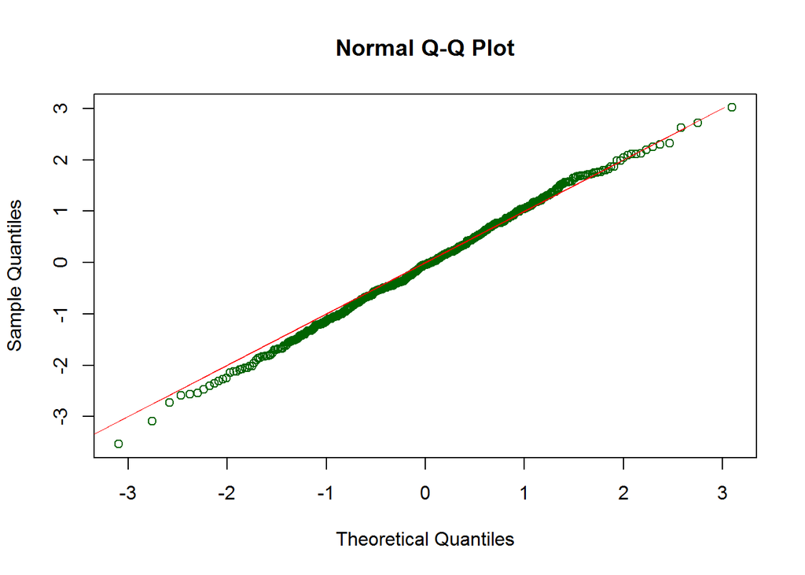

```r
# QQ Norm plot (Copied from plot.gamlss)
residx <- resid(model)
qqnorm(residx, main = "Normal Q-Q Plot",
            xlab = "Theoretical Quantiles",
            ylab = "Sample Quantiles",
            plot.it = TRUE,
            frame.plot = TRUE,
            col="darkgreen")
lines(residx, residx, col="red" , lwd=.4, cex=.4 )
```

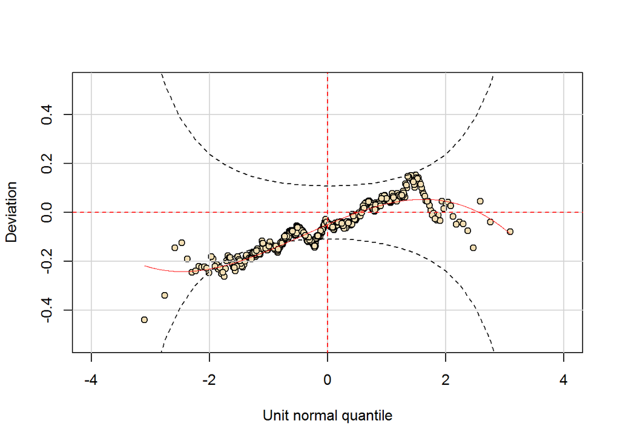

```r
# Worm Plot
wp(model)
```

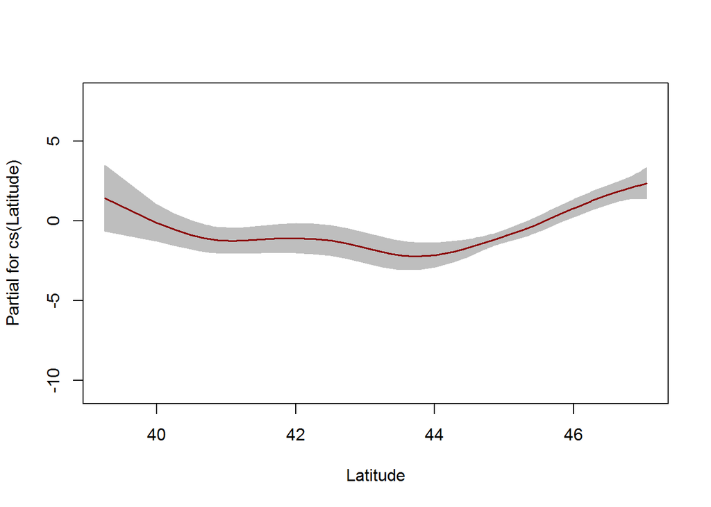

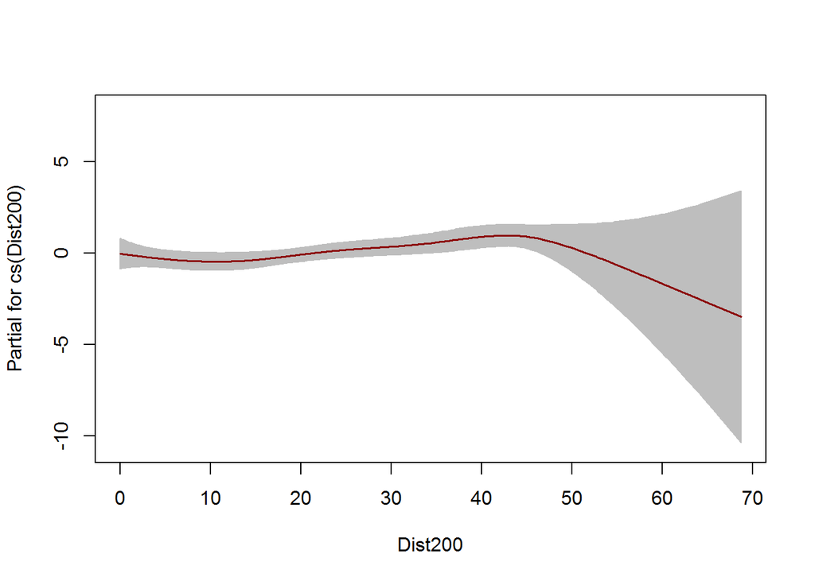

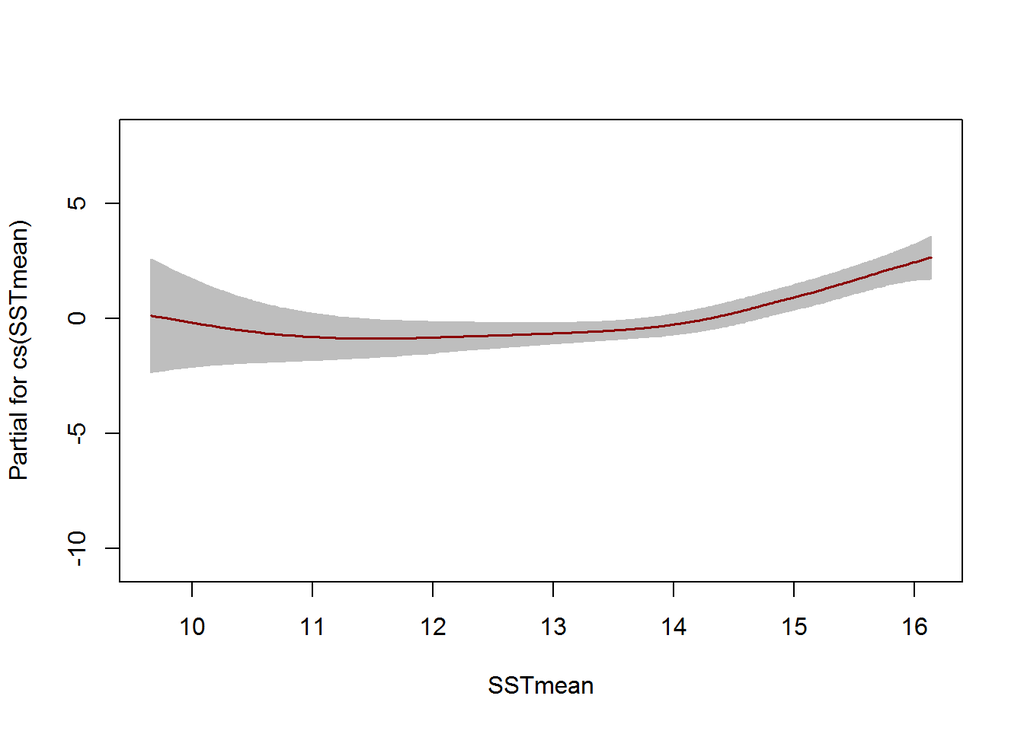

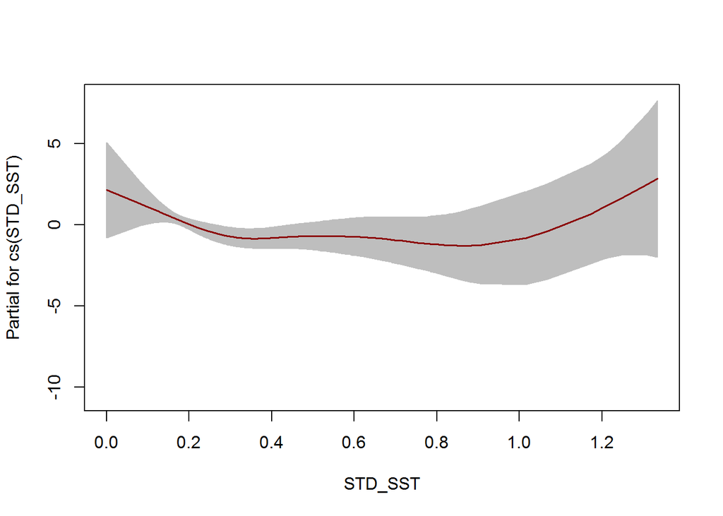

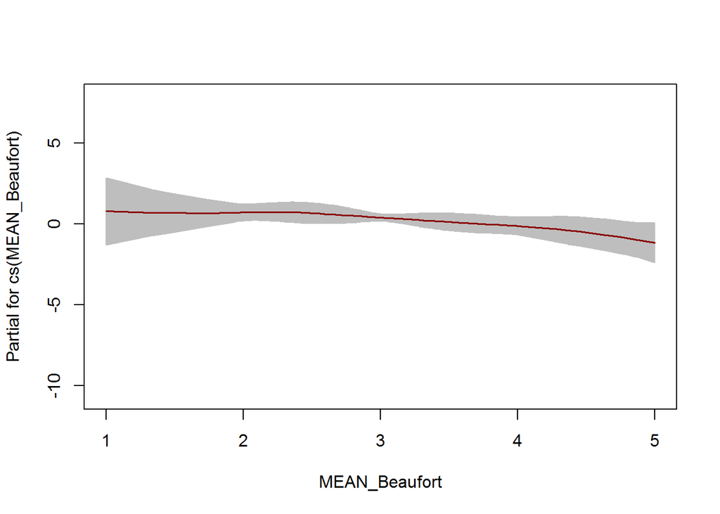

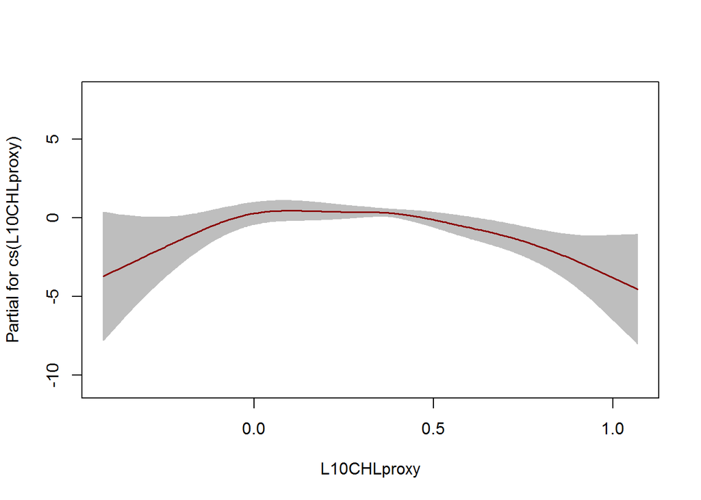

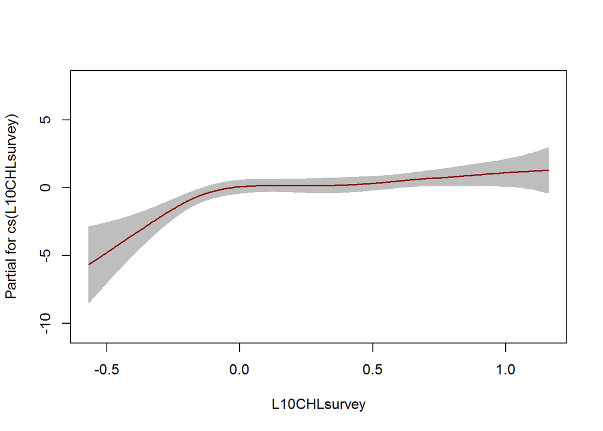

```r
# Term Plots
term.plot(model)
```

### Month 7

```r
model <- combined7culled

# Coefficients
summary(model)
```

```
## Family:  c("SI", "Sichel")
##
## Call:  gamlss(formula = SOSHcount ~ cs(Latitude) + cs(DistCoast) + cs(FCPI) +
##     offset(log(Binarea)), family = SI, data = month7, control = gamlss.control(n.cyc = 100))
##
## Fitting method: RS()
##
## -------------------------------------------------------------------
## Mu link function:  log
## Mu Coefficients:
##                Estimate Std. Error t value Pr(>|t|)
## (Intercept)   -7.074392   3.147656  -2.248   0.0250 *
## cs(Latitude)   0.280539   0.048688   5.762 1.39e-08 ***
## cs(DistCoast) -0.038867   0.007655  -5.078 5.25e-07 ***
## cs(FCPI)      -5.436883   3.119356  -1.743   0.0819 .
## ---
## Signif. codes:  0 '***' 0.001 '**' 0.01 '*' 0.05 '.' 0.1 ' ' 1
##
## -------------------------------------------------------------------
## Sigma link function:  log
## Sigma Coefficients:
##             Estimate Std. Error t value Pr(>|t|)
## (Intercept)    4.346      2.075   2.094   0.0367 *
## ---
## Signif. codes:  0 '***' 0.001 '**' 0.01 '*' 0.05 '.' 0.1 ' ' 1
##
## -------------------------------------------------------------------
## Nu link function:  identity
## Nu Coefficients:
##             Estimate Std. Error t value Pr(>|t|)
## (Intercept)  -1.0665     0.1369  -7.793 3.34e-14 ***
## ---
## Signif. codes:  0 '***' 0.001 '**' 0.01 '*' 0.05 '.' 0.1 ' ' 1
##
## -------------------------------------------------------------------
## NOTE: Additive smoothing terms exist in the formulas:
##  i) Std. Error for smoothers are for the linear effect only.
## ii) Std. Error for the linear terms maybe are not accurate.
## -------------------------------------------------------------------
## No. of observations in the fit:  561
## Degrees of Freedom for the fit:  16.36405
##       Residual Deg. of Freedom:  544.636
##                       at cycle:  19
##
## Global Deviance:     753.946
##             AIC:     786.6741
##             SBC:     857.5259
```

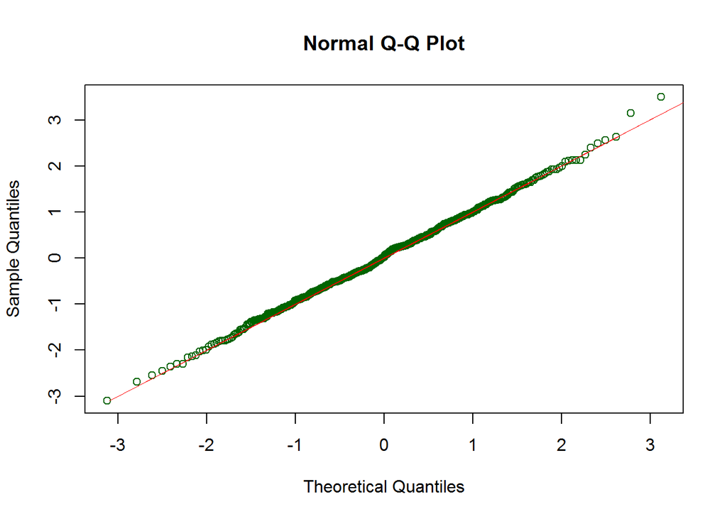

```r
# QQ Norm plot (Copied from plot.gamlss)
residx <- resid(model)
qqnorm(residx, main = "Normal Q-Q Plot",
            xlab = "Theoretical Quantiles",
            ylab = "Sample Quantiles",
            plot.it = TRUE,
            frame.plot = TRUE,
            col="darkgreen")
lines(residx, residx, col="red" , lwd=.4, cex=.4 )
```

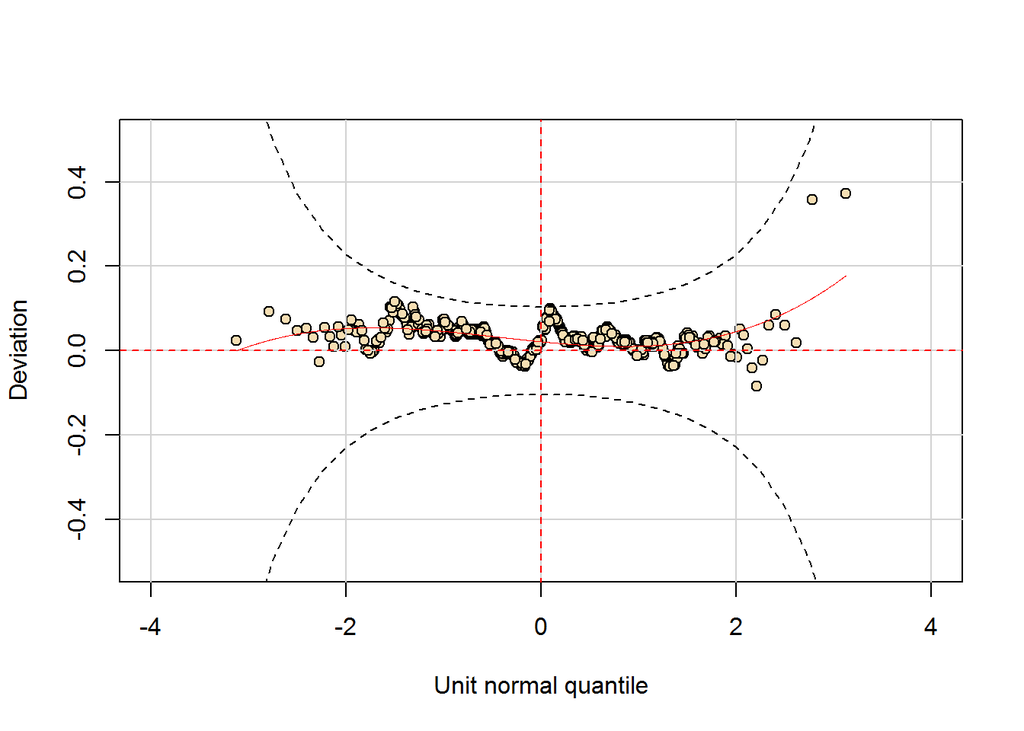

```r
# Worm Plot
wp(model)
```

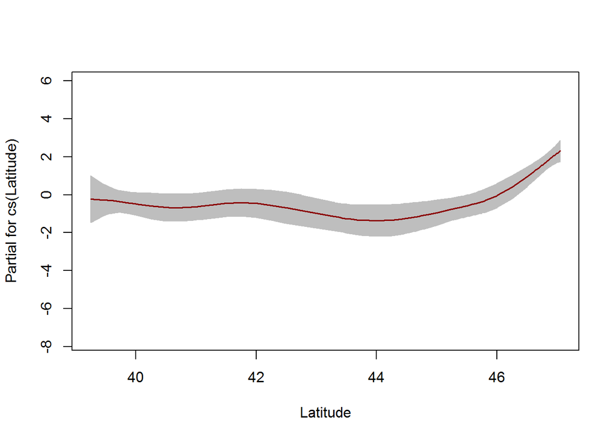

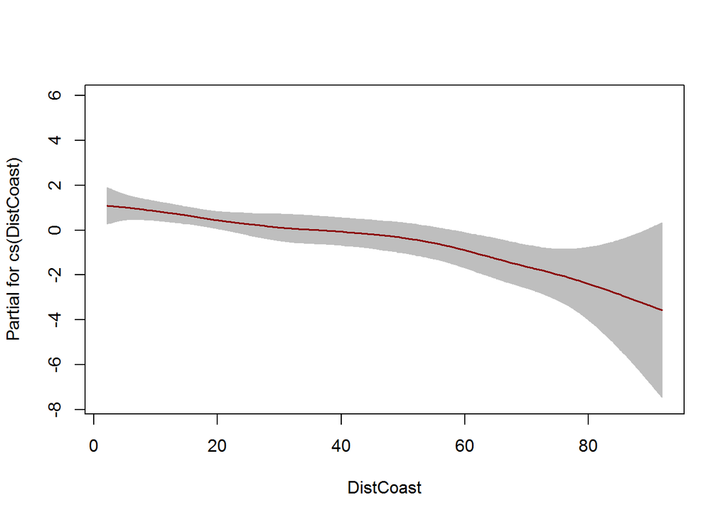

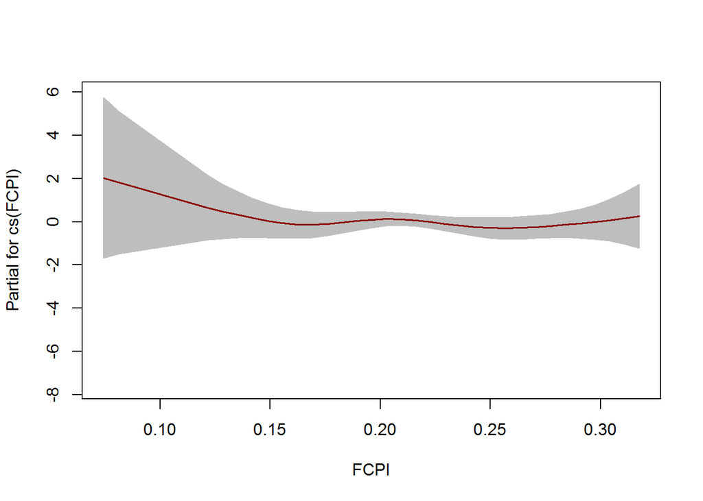

```r
# Term Plots
term.plot(model)
```

### Month 9

```r
model <- geo9culled

# Coefficients
summary(model)
```

```
## Family:  c("SI", "Sichel")
##
## Call:  gamlss(formula = formula, family = family, data = data, start.from = model,      iter = 40, n.cyc = 80)
##
## Fitting method: RS()
##
## -------------------------------------------------------------------
## Mu link function:  log
## Mu Coefficients:
##                 Estimate Std. Error t value Pr(>|t|)
## (Intercept)   -10.319538   2.051499  -5.030 6.64e-07 ***
## cs(Latitude)    0.277136   0.045709   6.063 2.48e-09 ***
## cs(DistCoast)  -0.057057   0.006043  -9.443  < 2e-16 ***
## cs(Dist200)     0.026559   0.007895   3.364 0.000822 ***
## cs(DepCI)       1.013860   0.431325   2.351 0.019097 *
## ---
## Signif. codes:  0 '***' 0.001 '**' 0.01 '*' 0.05 '.' 0.1 ' ' 1
##
## -------------------------------------------------------------------
## Sigma link function:  log
## Sigma Coefficients:
##             Estimate Std. Error t value Pr(>|t|)
## (Intercept)   1.9506     0.1089   17.92   <2e-16 ***
## ---
## Signif. codes:  0 '***' 0.001 '**' 0.01 '*' 0.05 '.' 0.1 ' ' 1
##
## -------------------------------------------------------------------
## Nu link function:  identity
## Nu Coefficients:
##             Estimate Std. Error t value Pr(>|t|)
## (Intercept)  -0.9598     0.0523  -18.35   <2e-16 ***
## ---
## Signif. codes:  0 '***' 0.001 '**' 0.01 '*' 0.05 '.' 0.1 ' ' 1
##
## -------------------------------------------------------------------
## NOTE: Additive smoothing terms exist in the formulas:
##  i) Std. Error for smoothers are for the linear effect only.
## ii) Std. Error for the linear terms may not be reliable.
## -------------------------------------------------------------------
## No. of observations in the fit:  569
## Degrees of Freedom for the fit:  21.06846
##       Residual Deg. of Freedom:  547.9315
##                       at cycle:  50
##
## Global Deviance:     1264.906
##             AIC:     1307.043
##             SBC:     1398.562
```

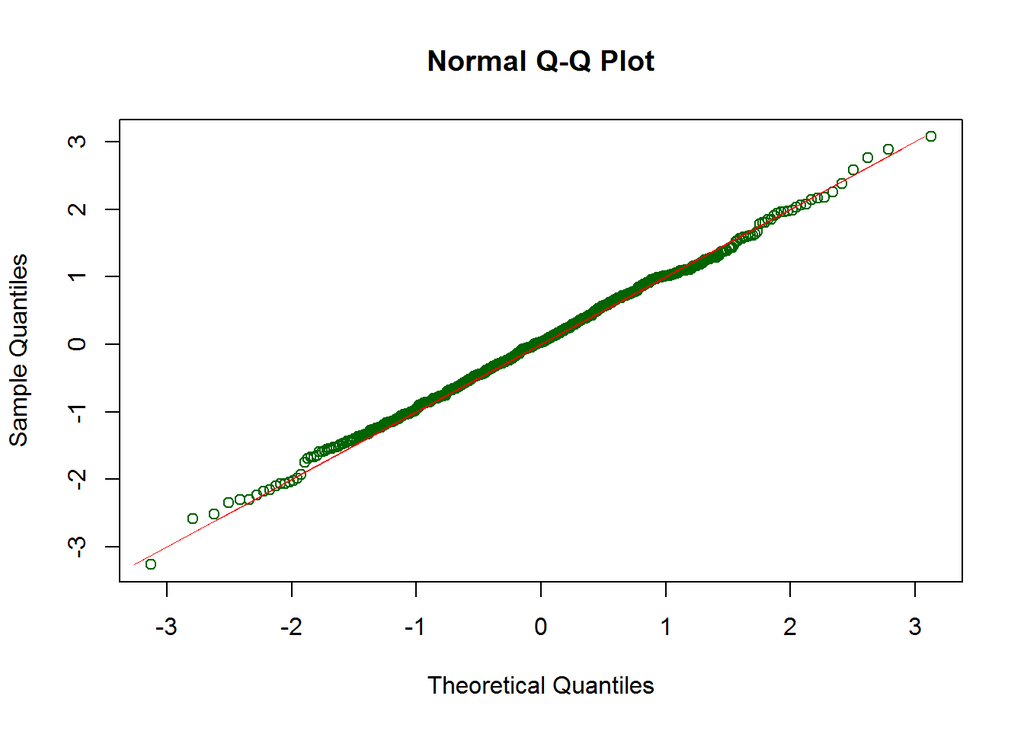

```r
# QQ Norm plot (Copied from plot.gamlss)
residx <- resid(model)
qqnorm(residx, main = "Normal Q-Q Plot",
            xlab = "Theoretical Quantiles",
            ylab = "Sample Quantiles",
            plot.it = TRUE,
            frame.plot = TRUE,
            col="darkgreen")
lines(residx, residx, col="red" , lwd=.4, cex=.4 )
```

```r
# Worm Plot
# wp(model)
# Worm plot error in month 9

# Term Plots
# term.plot(model)
# Term plots error in month 9
```

### Month 10

```r
model <- combined10culled

# Coefficients
summary(model)
```

```
## Family:  c("SI", "Sichel")
##
## Call:  gamlss(formula = SOSHcount ~ cs(Latitude) + cs(DistCoast) + cs(SSTmean) +
##     cs(STD_SST) + cs(L10CHLproxy) + cs(L10CHLsurvclim) + offset(log(Binarea)),
##     family = SI, data = month10, control = gamlss.control(n.cyc = 100))
##
## Fitting method: RS()
##
## -------------------------------------------------------------------
## Mu link function:  log
## Mu Coefficients:
##                      Estimate Std. Error t value Pr(>|t|)
## (Intercept)        -45.010175   9.045625  -4.976 8.88e-07 ***
## cs(Latitude)         0.604265   0.158201   3.820 0.000150 ***
## cs(DistCoast)       -0.008716   0.013046  -0.668 0.504381
## cs(SSTmean)          1.672157   0.267800   6.244 8.96e-10 ***
## cs(STD_SST)        -12.280922   3.698859  -3.320 0.000964 ***
## cs(L10CHLproxy)     -1.511414   0.923704  -1.636 0.102401
## cs(L10CHLsurvclim)  -1.122233   1.298599  -0.864 0.387890
## ---
## Signif. codes:  0 '***' 0.001 '**' 0.01 '*' 0.05 '.' 0.1 ' ' 1
##
## -------------------------------------------------------------------
## Sigma link function:  log
## Sigma Coefficients:
##             Estimate Std. Error t value Pr(>|t|)
## (Intercept)   4.7151     0.1472   32.03   <2e-16 ***
## ---
## Signif. codes:  0 '***' 0.001 '**' 0.01 '*' 0.05 '.' 0.1 ' ' 1
##
## -------------------------------------------------------------------
## Nu link function:  identity
## Nu Coefficients:
##             Estimate Std. Error t value Pr(>|t|)
## (Intercept) -0.89352    0.04957  -18.02   <2e-16 ***
## ---
## Signif. codes:  0 '***' 0.001 '**' 0.01 '*' 0.05 '.' 0.1 ' ' 1
##
## -------------------------------------------------------------------
## NOTE: Additive smoothing terms exist in the formulas:
##  i) Std. Error for smoothers are for the linear effect only.
## ii) Std. Error for the linear terms may not be reliable.
## -------------------------------------------------------------------
## No. of observations in the fit:  538
## Degrees of Freedom for the fit:  28.01191
##       Residual Deg. of Freedom:  509.9881
##                       at cycle:  38
##
## Global Deviance:     779.0697
##             AIC:     835.0935
##             SBC:     955.2047
```

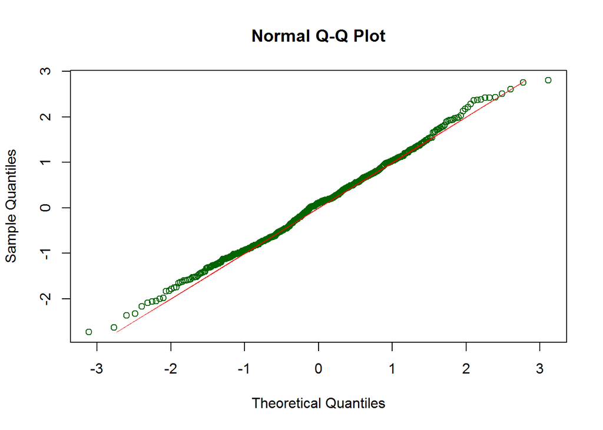

```r
# QQ Norm plot (Copied from plot.gamlss)
residx <- resid(model)
qqnorm(residx, main = "Normal Q-Q Plot",
            xlab = "Theoretical Quantiles",
            ylab = "Sample Quantiles",
            plot.it = TRUE,
            frame.plot = TRUE,
            col="darkgreen")
lines(residx, residx, col="red" , lwd=.4, cex=.4 )
```

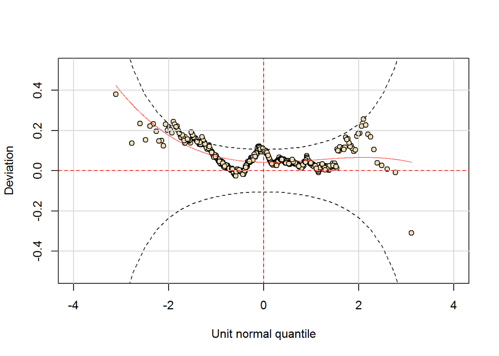

```r
# Worm Plot
wp(model)
```

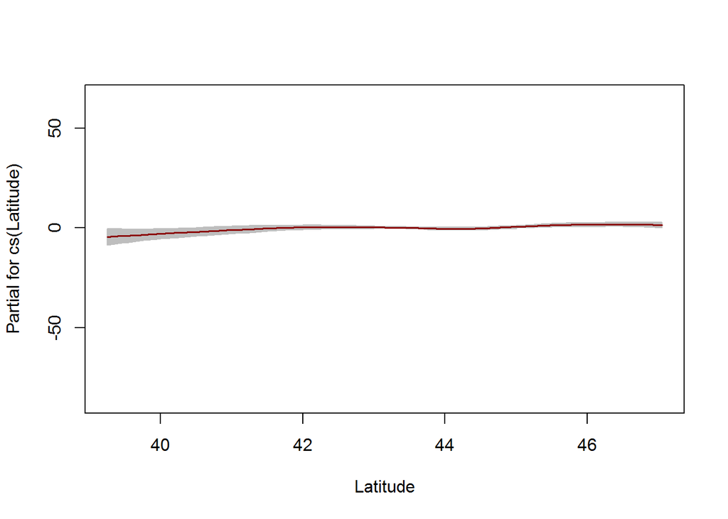

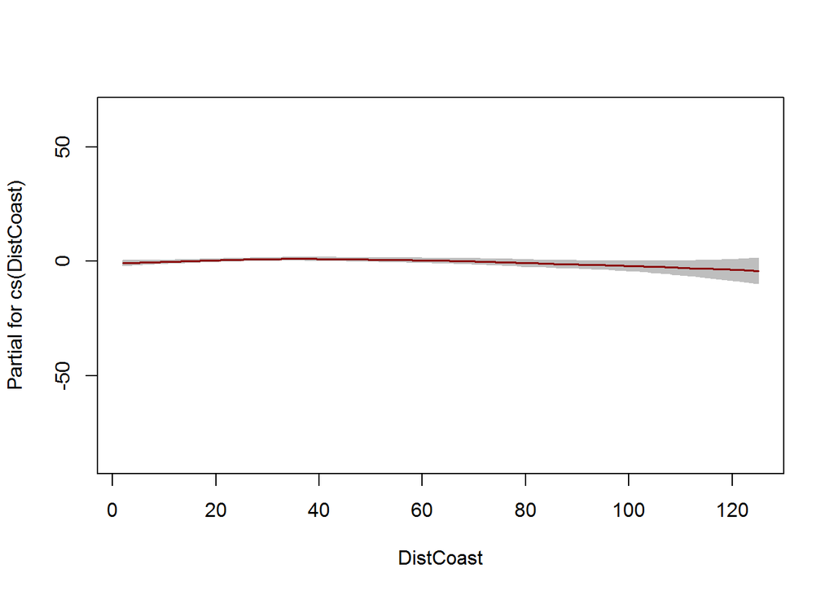

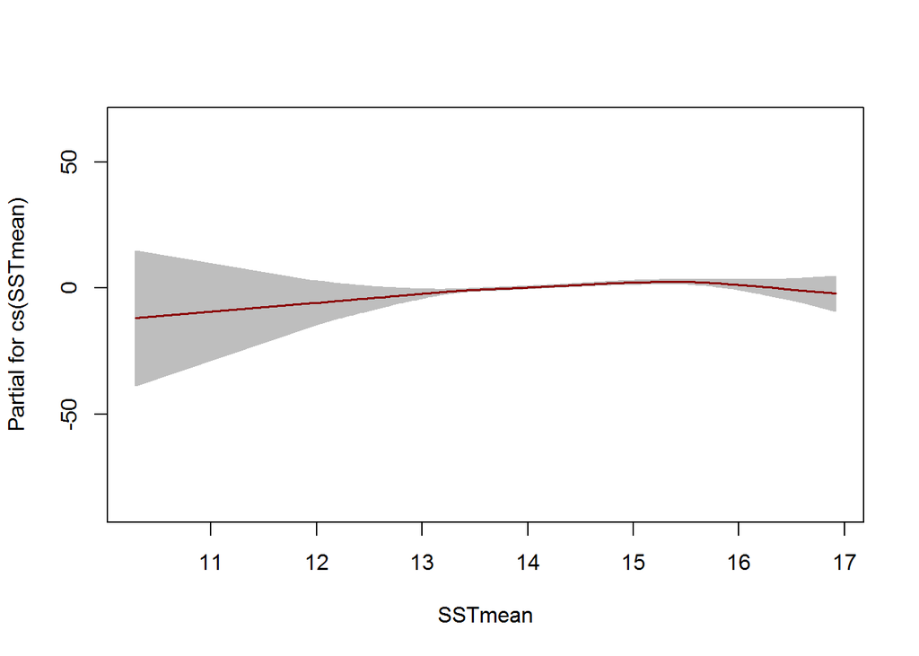

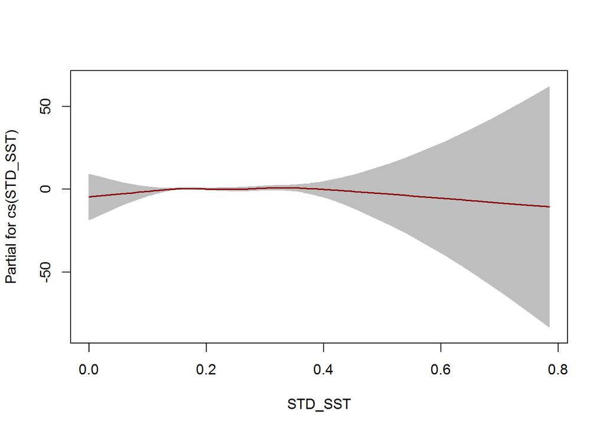

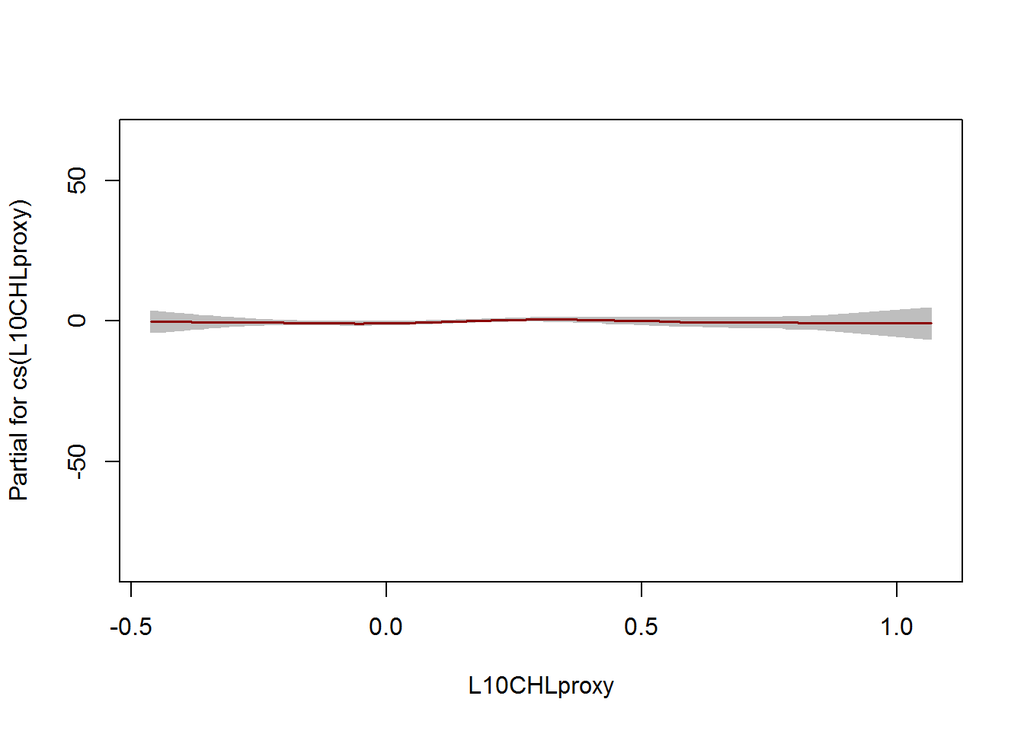

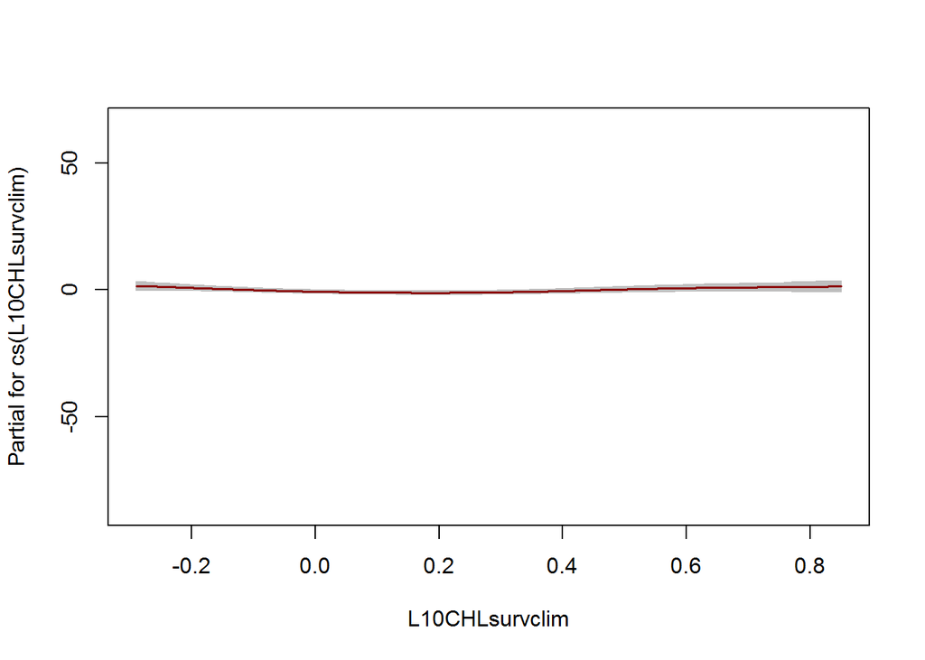

```r
# Term Plots
term.plot(model)
```

### Augment monthly models with UD variable

1. Season specific (6 and 7, or 9 and 10) and full survey period (6 – 10) shearwater BBUDs were added to the top-ranking model in each month to evaluate potential for increasing model fit based on gAIC.
2. What works best?

```r
month6 <- filter(sosh.data, Month == 6)
ud6seasonal <- gamlss(SOSHcount ~ cs(Latitude) + cs(Dist200) + cs(SSTmean) + cs(STD_SST) +
                        cs(MEAN_Beaufort) + cs(L10CHLproxy) + cs(L10CHLsurvey) + offset(log(Binarea)) +
                        SOSH0607UD,
                      family = SI,
                      data = month6,
                      control = gamlss.control(n.cyc = 100))
```

```
## GAMLSS-RS iteration 1: Global Deviance = 1427.483
## GAMLSS-RS iteration 2: Global Deviance = 1427.628
## GAMLSS-RS iteration 3: Global Deviance = 1428.03
## GAMLSS-RS iteration 4: Global Deviance = 1428.33
## GAMLSS-RS iteration 5: Global Deviance = 1428.509
## GAMLSS-RS iteration 6: Global Deviance = 1428.6
## GAMLSS-RS iteration 7: Global Deviance = 1428.622
## GAMLSS-RS iteration 8: Global Deviance = 1428.6
## GAMLSS-RS iteration 9: Global Deviance = 1428.509
## GAMLSS-RS iteration 10: Global Deviance = 1428.438
## GAMLSS-RS iteration 11: Global Deviance = 1428.332
## GAMLSS-RS iteration 12: Global Deviance = 1428.272
## GAMLSS-RS iteration 13: Global Deviance = 1428.15
## GAMLSS-RS iteration 14: Global Deviance = 1428.023
## GAMLSS-RS iteration 15: Global Deviance = 1427.894
## GAMLSS-RS iteration 16: Global Deviance = 1427.766
## GAMLSS-RS iteration 17: Global Deviance = 1427.634
## GAMLSS-RS iteration 18: Global Deviance = 1427.506
## GAMLSS-RS iteration 19: Global Deviance = 1427.378
## GAMLSS-RS iteration 20: Global Deviance = 1427.256
## GAMLSS-RS iteration 21: Global Deviance = 1427.131
## GAMLSS-RS iteration 22: Global Deviance = 1427.008
## GAMLSS-RS iteration 23: Global Deviance = 1426.888
## GAMLSS-RS iteration 24: Global Deviance = 1426.773
## GAMLSS-RS iteration 25: Global Deviance = 1426.661
## GAMLSS-RS iteration 26: Global Deviance = 1426.552
## GAMLSS-RS iteration 27: Global Deviance = 1426.446
## GAMLSS-RS iteration 28: Global Deviance = 1426.342
## GAMLSS-RS iteration 29: Global Deviance = 1426.242
## GAMLSS-RS iteration 30: Global Deviance = 1426.145
## GAMLSS-RS iteration 31: Global Deviance = 1426.05
## GAMLSS-RS iteration 32: Global Deviance = 1425.958
## GAMLSS-RS iteration 33: Global Deviance = 1425.87
## GAMLSS-RS iteration 34: Global Deviance = 1425.784
## GAMLSS-RS iteration 35: Global Deviance = 1425.702
## GAMLSS-RS iteration 36: Global Deviance = 1425.622
## GAMLSS-RS iteration 37: Global Deviance = 1425.545
## GAMLSS-RS iteration 38: Global Deviance = 1425.471
## GAMLSS-RS iteration 39: Global Deviance = 1425.4
## GAMLSS-RS iteration 40: Global Deviance = 1425.331
```

[output cut: 45 more lines]

```
## GAMLSS-RS iteration 86: Global Deviance = 1423.989
## GAMLSS-RS iteration 87: Global Deviance = 1423.98
## GAMLSS-RS iteration 88: Global Deviance = 1423.972
## GAMLSS-RS iteration 89: Global Deviance = 1423.964
## GAMLSS-RS iteration 90: Global Deviance = 1423.957
## GAMLSS-RS iteration 91: Global Deviance = 1423.951
## GAMLSS-RS iteration 92: Global Deviance = 1423.945
## GAMLSS-RS iteration 93: Global Deviance = 1423.94
## GAMLSS-RS iteration 94: Global Deviance = 1423.935
## GAMLSS-RS iteration 95: Global Deviance = 1423.928
## GAMLSS-RS iteration 96: Global Deviance = 1423.924
## GAMLSS-RS iteration 97: Global Deviance = 1423.92
## GAMLSS-RS iteration 98: Global Deviance = 1423.915
## GAMLSS-RS iteration 99: Global Deviance = 1423.912
## GAMLSS-RS iteration 100: Global Deviance = 1423.907
```

```r
ud6total <- gamlss(SOSHcount ~ cs(Latitude) + cs(Dist200) + cs(SSTmean) + cs(STD_SST) +
                        cs(MEAN_Beaufort) + cs(L10CHLproxy) + cs(L10CHLsurvey) + offset(log(Binarea)) +
                        SOSH0610UD,
                      family = SI,
                      data = month6,
                      control = gamlss.control(n.cyc = 100))
```

```
## GAMLSS-RS iteration 1: Global Deviance = 1427.067
## GAMLSS-RS iteration 2: Global Deviance = 1427.528
## GAMLSS-RS iteration 3: Global Deviance = 1427.962
## GAMLSS-RS iteration 4: Global Deviance = 1428.244
## GAMLSS-RS iteration 5: Global Deviance = 1428.405
## GAMLSS-RS iteration 6: Global Deviance = 1428.472
## GAMLSS-RS iteration 7: Global Deviance = 1428.46
## GAMLSS-RS iteration 8: Global Deviance = 1428.362
## GAMLSS-RS iteration 9: Global Deviance = 1428.266
## GAMLSS-RS iteration 10: Global Deviance = 1428.165
## GAMLSS-RS iteration 11: Global Deviance = 1428.056
## GAMLSS-RS iteration 12: Global Deviance = 1427.944
## GAMLSS-RS iteration 13: Global Deviance = 1427.831
## GAMLSS-RS iteration 14: Global Deviance = 1427.718
## GAMLSS-RS iteration 15: Global Deviance = 1427.604
## GAMLSS-RS iteration 16: Global Deviance = 1427.492
## GAMLSS-RS iteration 17: Global Deviance = 1427.38
## GAMLSS-RS iteration 18: Global Deviance = 1427.268
## GAMLSS-RS iteration 19: Global Deviance = 1427.158
## GAMLSS-RS iteration 20: Global Deviance = 1427.061
## GAMLSS-RS iteration 21: Global Deviance = 1426.923
## GAMLSS-RS iteration 22: Global Deviance = 1426.837
## GAMLSS-RS iteration 23: Global Deviance = 1426.733
## GAMLSS-RS iteration 24: Global Deviance = 1426.601
## GAMLSS-RS iteration 25: Global Deviance = 1426.469
## GAMLSS-RS iteration 26: Global Deviance = 1426.335
## GAMLSS-RS iteration 27: Global Deviance = 1426.201
## GAMLSS-RS iteration 28: Global Deviance = 1426.074
## GAMLSS-RS iteration 29: Global Deviance = 1425.952
## GAMLSS-RS iteration 30: Global Deviance = 1425.832
## GAMLSS-RS iteration 31: Global Deviance = 1425.717
## GAMLSS-RS iteration 32: Global Deviance = 1425.605
## GAMLSS-RS iteration 33: Global Deviance = 1425.497
## GAMLSS-RS iteration 34: Global Deviance = 1425.394
## GAMLSS-RS iteration 35: Global Deviance = 1425.295
## GAMLSS-RS iteration 36: Global Deviance = 1425.199
## GAMLSS-RS iteration 37: Global Deviance = 1425.106
## GAMLSS-RS iteration 38: Global Deviance = 1425.018
## GAMLSS-RS iteration 39: Global Deviance = 1424.934
## GAMLSS-RS iteration 40: Global Deviance = 1424.853
```

[output cut: 40 more lines]

```
## GAMLSS-RS iteration 81: Global Deviance = 1423.431
## GAMLSS-RS iteration 82: Global Deviance = 1423.42
## GAMLSS-RS iteration 83: Global Deviance = 1423.412
## GAMLSS-RS iteration 84: Global Deviance = 1423.401
## GAMLSS-RS iteration 85: Global Deviance = 1423.394
## GAMLSS-RS iteration 86: Global Deviance = 1423.386
## GAMLSS-RS iteration 87: Global Deviance = 1423.373
## GAMLSS-RS iteration 88: Global Deviance = 1423.368
## GAMLSS-RS iteration 89: Global Deviance = 1423.357
## GAMLSS-RS iteration 90: Global Deviance = 1423.352
## GAMLSS-RS iteration 91: Global Deviance = 1423.345
## GAMLSS-RS iteration 92: Global Deviance = 1423.341
## GAMLSS-RS iteration 93: Global Deviance = 1423.334
## GAMLSS-RS iteration 94: Global Deviance = 1423.33
## GAMLSS-RS iteration 95: Global Deviance = 1423.329
```

```r
month7 <- filter(sosh.data, Month == 7)
ud7seasonal <- gamlss(SOSHcount ~ cs(Latitude) + cs(DistCoast) + cs(FCPI) + offset(log(Binarea)) +
                        SOSH0607UD,
                      family = SI,
                      data = month7,
                      control = gamlss.control(n.cyc = 100))
```

```
## GAMLSS-RS iteration 1: Global Deviance = 773.6894
## GAMLSS-RS iteration 2: Global Deviance = 766.9032
## GAMLSS-RS iteration 3: Global Deviance = 762.4528
## GAMLSS-RS iteration 4: Global Deviance = 759.1206
## GAMLSS-RS iteration 5: Global Deviance = 756.8281
## GAMLSS-RS iteration 6: Global Deviance = 755.1033
## GAMLSS-RS iteration 7: Global Deviance = 754.1709
## GAMLSS-RS iteration 8: Global Deviance = 753.4478
## GAMLSS-RS iteration 9: Global Deviance = 752.9691
## GAMLSS-RS iteration 10: Global Deviance = 752.725
## GAMLSS-RS iteration 11: Global Deviance = 752.4976
## GAMLSS-RS iteration 12: Global Deviance = 752.3813
## GAMLSS-RS iteration 13: Global Deviance = 752.3215
## GAMLSS-RS iteration 14: Global Deviance = 752.2666
## GAMLSS-RS iteration 15: Global Deviance = 752.2409
## GAMLSS-RS iteration 16: Global Deviance = 752.2297
## GAMLSS-RS iteration 17: Global Deviance = 752.2152
## GAMLSS-RS iteration 18: Global Deviance = 752.2149
```

```r
ud7total <- gamlss(SOSHcount ~ cs(Latitude) + cs(DistCoast) + cs(FCPI) + offset(log(Binarea)) +
                        SOSH0610UD,
                      family = SI,
                      data = month7,
                      control = gamlss.control(n.cyc = 200))
```

```
## GAMLSS-RS iteration 1: Global Deviance = 772.22
## GAMLSS-RS iteration 2: Global Deviance = 765.3725
## GAMLSS-RS iteration 3: Global Deviance = 760.5893
## GAMLSS-RS iteration 4: Global Deviance = 757.2894
## GAMLSS-RS iteration 5: Global Deviance = 754.8029
## GAMLSS-RS iteration 6: Global Deviance = 753.1456
## GAMLSS-RS iteration 7: Global Deviance = 752.0933
## GAMLSS-RS iteration 8: Global Deviance = 751.3185
## GAMLSS-RS iteration 9: Global Deviance = 750.857
## GAMLSS-RS iteration 10: Global Deviance = 750.5464
## GAMLSS-RS iteration 11: Global Deviance = 750.343
## GAMLSS-RS iteration 12: Global Deviance = 750.1965
## GAMLSS-RS iteration 13: Global Deviance = 750.1329
## GAMLSS-RS iteration 14: Global Deviance = 750.0923
## GAMLSS-RS iteration 15: Global Deviance = 750.0026
## GAMLSS-RS iteration 16: Global Deviance = 749.9692
## GAMLSS-RS iteration 17: Global Deviance = 750.0227
## GAMLSS-RS iteration 18: Global Deviance = 749.9858
## GAMLSS-RS iteration 19: Global Deviance = 749.9802
## GAMLSS-RS iteration 20: Global Deviance = 749.9947
## GAMLSS-RS iteration 21: Global Deviance = 750.0155
## GAMLSS-RS iteration 22: Global Deviance = 749.9976
## GAMLSS-RS iteration 23: Global Deviance = 750.0007
## GAMLSS-RS iteration 24: Global Deviance = 750.0088
## GAMLSS-RS iteration 25: Global Deviance = 750.0103
## GAMLSS-RS iteration 26: Global Deviance = 750.0516
## GAMLSS-RS iteration 27: Global Deviance = 750.0125
## GAMLSS-RS iteration 28: Global Deviance = 750.0107
## GAMLSS-RS iteration 29: Global Deviance = 750.0202
## GAMLSS-RS iteration 30: Global Deviance = 750.0188
## GAMLSS-RS iteration 31: Global Deviance = 750.0387
## GAMLSS-RS iteration 32: Global Deviance = 750.0182
## GAMLSS-RS iteration 33: Global Deviance = 750.0157
## GAMLSS-RS iteration 34: Global Deviance = 750.0218
## GAMLSS-RS iteration 35: Global Deviance = 750.0239
## GAMLSS-RS iteration 36: Global Deviance = 750.0389
## GAMLSS-RS iteration 37: Global Deviance = 750.0187
## GAMLSS-RS iteration 38: Global Deviance = 750.0148
## GAMLSS-RS iteration 39: Global Deviance = 750.0252
## GAMLSS-RS iteration 40: Global Deviance = 750.0204
```

[output cut: 106 more lines]

```
## GAMLSS-RS iteration 147: Global Deviance = 749.983
## GAMLSS-RS iteration 148: Global Deviance = 750.0255
## GAMLSS-RS iteration 149: Global Deviance = 749.9807
## GAMLSS-RS iteration 150: Global Deviance = 749.9761
## GAMLSS-RS iteration 151: Global Deviance = 749.9747
## GAMLSS-RS iteration 152: Global Deviance = 749.9823
## GAMLSS-RS iteration 153: Global Deviance = 750.0092
## GAMLSS-RS iteration 154: Global Deviance = 749.9808
## GAMLSS-RS iteration 155: Global Deviance = 750.0025
## GAMLSS-RS iteration 156: Global Deviance = 749.9756
## GAMLSS-RS iteration 157: Global Deviance = 749.9972
## GAMLSS-RS iteration 158: Global Deviance = 749.9781
## GAMLSS-RS iteration 159: Global Deviance = 749.9731
## GAMLSS-RS iteration 160: Global Deviance = 749.9833
## GAMLSS-RS iteration 161: Global Deviance = 749.9823
```

```r
month9 <- filter(sosh.data, Month == 9)
ud9seasonal <- try.fit(SOSHcount ~ cs(Latitude) + cs(DistCoast) + cs(Dist200) + cs(DepCI) +
                         offset(log(Binarea)) + SOSH0910UD,
                       family = SI,
                       data = month9)
```

```
## GAMLSS-RS iteration 1: Global Deviance = 1267.067
```

[output not shown]

[output cut: 10 more lines]

[output not shown]

```
## GAMLSS-RS iteration 2: Global Deviance = 1262.184
```

```
## GAMLSS-RS iteration 3: Global Deviance = 1259.842
```

```
## GAMLSS-RS iteration 4: Global Deviance = 1258.781
```

```
## GAMLSS-RS iteration 5: Global Deviance = 1258.219
```

```
## GAMLSS-RS iteration 6: Global Deviance = 1258.077
```

```
## GAMLSS-RS iteration 7: Global Deviance = 1258.208
## GAMLSS-RS iteration 8: Global Deviance = 1258.02
```

```
## GAMLSS-RS iteration 9: Global Deviance = 1258.365
## GAMLSS-RS iteration 10: Global Deviance = 1258.375
```

```
## GAMLSS-RS iteration 11: Global Deviance = 1258.491
## GAMLSS-RS iteration 12: Global Deviance = 1258.521
## GAMLSS-RS iteration 13: Global Deviance = 1258.714
## GAMLSS-RS iteration 14: Global Deviance = 1258.696
## GAMLSS-RS iteration 15: Global Deviance = 1258.914
```

```
## GAMLSS-RS iteration 16: Global Deviance = 1258.805
```

```
## GAMLSS-RS iteration 17: Global Deviance = 1258.655
## GAMLSS-RS iteration 18: Global Deviance = 1258.885
## GAMLSS-RS iteration 19: Global Deviance = 1258.91
## GAMLSS-RS iteration 20: Global Deviance = 1258.991
```

```
## GAMLSS-RS iteration 21: Global Deviance = 1259.799
## GAMLSS-RS iteration 22: Global Deviance = 1259.833
## GAMLSS-RS iteration 23: Global Deviance = 1259.847
## GAMLSS-RS iteration 24: Global Deviance = 1259.864
## GAMLSS-RS iteration 25: Global Deviance = 1259.859
## GAMLSS-RS iteration 26: Global Deviance = 1259.853
## GAMLSS-RS iteration 27: Global Deviance = 1259.855
## GAMLSS-RS iteration 28: Global Deviance = 1259.888
## GAMLSS-RS iteration 29: Global Deviance = 1259.872
## GAMLSS-RS iteration 30: Global Deviance = 1259.88
## GAMLSS-RS iteration 31: Global Deviance = 1259.906
## GAMLSS-RS iteration 32: Global Deviance = 1259.863
## GAMLSS-RS iteration 33: Global Deviance = 1259.877
## GAMLSS-RS iteration 34: Global Deviance = 1259.882
## GAMLSS-RS iteration 35: Global Deviance = 1259.873
## GAMLSS-RS iteration 36: Global Deviance = 1259.878
## GAMLSS-RS iteration 37: Global Deviance = 1259.882
## GAMLSS-RS iteration 38: Global Deviance = 1259.892
## GAMLSS-RS iteration 39: Global Deviance = 1259.892
```

```r
ud9total <- try.fit(SOSHcount ~ cs(Latitude) + cs(DistCoast) + cs(Dist200) + cs(DepCI) +
                         offset(log(Binarea)) + SOSH0610UD,
                       family = SI,
                       data = month9)
```

```
## GAMLSS-RS iteration 1: Global Deviance = 1265.568
```

```
## GAMLSS-RS iteration 2: Global Deviance = 1260.68
## GAMLSS-RS iteration 3: Global Deviance = 1258.186
```

```
## GAMLSS-RS iteration 4: Global Deviance = 1256.974
```

```
## GAMLSS-RS iteration 5: Global Deviance = 1256.233
## GAMLSS-RS iteration 6: Global Deviance = 1256.127
## GAMLSS-RS iteration 7: Global Deviance = 1255.991
## GAMLSS-RS iteration 8: Global Deviance = 1256.055
## GAMLSS-RS iteration 9: Global Deviance = 1256.172
## GAMLSS-RS iteration 10: Global Deviance = 1256.214
## GAMLSS-RS iteration 11: Global Deviance = 1256.228
## GAMLSS-RS iteration 12: Global Deviance = 1256.274
## GAMLSS-RS iteration 13: Global Deviance = 1256.418
## GAMLSS-RS iteration 14: Global Deviance = 1256.428
## GAMLSS-RS iteration 15: Global Deviance = 1256.461
## GAMLSS-RS iteration 16: Global Deviance = 1256.568
## GAMLSS-RS iteration 17: Global Deviance = 1256.606
## GAMLSS-RS iteration 18: Global Deviance = 1256.605
## GAMLSS-RS iteration 19: Global Deviance = 1256.616
## GAMLSS-RS iteration 20: Global Deviance = 1256.604
```

```
## GAMLSS-RS iteration 21: Global Deviance = 1257.274
## GAMLSS-RS iteration 22: Global Deviance = 1257.272
## GAMLSS-RS iteration 23: Global Deviance = 1257.306
## GAMLSS-RS iteration 24: Global Deviance = 1257.31
## GAMLSS-RS iteration 25: Global Deviance = 1257.31
```

```r
month10 <- filter(sosh.data, Month == 10)
ud10seasonal <- gamlss(SOSHcount ~ cs(Latitude) + cs(DistCoast) + cs(SSTmean) + cs(STD_SST) +
                         cs(L10CHLproxy) + cs(L10CHLsurvclim) + offset(log(Binarea)) + SOSH0910UD,
                       family = SI,
                       data = month10,
                       control = gamlss.control(n.cyc = 100))
```

```
## GAMLSS-RS iteration 1: Global Deviance = 783.0406
## GAMLSS-RS iteration 2: Global Deviance = 779.9917
## GAMLSS-RS iteration 3: Global Deviance = 778.2737
## GAMLSS-RS iteration 4: Global Deviance = 777.391
## GAMLSS-RS iteration 5: Global Deviance = 777.0463
## GAMLSS-RS iteration 6: Global Deviance = 776.8841
## GAMLSS-RS iteration 7: Global Deviance = 777.0072
## GAMLSS-RS iteration 8: Global Deviance = 777.2014
## GAMLSS-RS iteration 9: Global Deviance = 777.3367
## GAMLSS-RS iteration 10: Global Deviance = 777.4649
## GAMLSS-RS iteration 11: Global Deviance = 777.5942
## GAMLSS-RS iteration 12: Global Deviance = 777.7246
## GAMLSS-RS iteration 13: Global Deviance = 777.8398
## GAMLSS-RS iteration 14: Global Deviance = 777.9079
## GAMLSS-RS iteration 15: Global Deviance = 777.9787
## GAMLSS-RS iteration 16: Global Deviance = 778.0478
## GAMLSS-RS iteration 17: Global Deviance = 778.0889
## GAMLSS-RS iteration 18: Global Deviance = 778.1134
## GAMLSS-RS iteration 19: Global Deviance = 778.1484
## GAMLSS-RS iteration 20: Global Deviance = 778.1677
## GAMLSS-RS iteration 21: Global Deviance = 778.1826
## GAMLSS-RS iteration 22: Global Deviance = 778.2059
## GAMLSS-RS iteration 23: Global Deviance = 778.211
## GAMLSS-RS iteration 24: Global Deviance = 778.211
```

```r
ud10total <- gamlss(SOSHcount ~ cs(Latitude) + cs(DistCoast) + cs(SSTmean) + cs(STD_SST) +
                      cs(L10CHLproxy) + cs(L10CHLsurvclim) + offset(log(Binarea)) + SOSH0610UD,
                    family = SI,
                    data = month10,
                    control = gamlss.control(n.cyc = 100))
```

```
## GAMLSS-RS iteration 1: Global Deviance = 783.6736
## GAMLSS-RS iteration 2: Global Deviance = 780.5769
## GAMLSS-RS iteration 3: Global Deviance = 778.9349
## GAMLSS-RS iteration 4: Global Deviance = 778.1195
## GAMLSS-RS iteration 5: Global Deviance = 777.7791
## GAMLSS-RS iteration 6: Global Deviance = 777.6259
## GAMLSS-RS iteration 7: Global Deviance = 777.7788
## GAMLSS-RS iteration 8: Global Deviance = 777.9286
## GAMLSS-RS iteration 9: Global Deviance = 777.9394
## GAMLSS-RS iteration 10: Global Deviance = 778.1819
## GAMLSS-RS iteration 11: Global Deviance = 778.4066
## GAMLSS-RS iteration 12: Global Deviance = 778.5239
## GAMLSS-RS iteration 13: Global Deviance = 778.62
## GAMLSS-RS iteration 14: Global Deviance = 778.7107
## GAMLSS-RS iteration 15: Global Deviance = 778.7726
## GAMLSS-RS iteration 16: Global Deviance = 778.8216
## GAMLSS-RS iteration 17: Global Deviance = 778.871
## GAMLSS-RS iteration 18: Global Deviance = 778.8821
## GAMLSS-RS iteration 19: Global Deviance = 778.9332
## GAMLSS-RS iteration 20: Global Deviance = 778.9582
## GAMLSS-RS iteration 21: Global Deviance = 778.9624
## GAMLSS-RS iteration 22: Global Deviance = 778.9804
## GAMLSS-RS iteration 23: Global Deviance = 778.9831
## GAMLSS-RS iteration 24: Global Deviance = 778.9907
## GAMLSS-RS iteration 25: Global Deviance = 779.0158
## GAMLSS-RS iteration 26: Global Deviance = 779.0129
## GAMLSS-RS iteration 27: Global Deviance = 779.0098
## GAMLSS-RS iteration 28: Global Deviance = 779.0052
## GAMLSS-RS iteration 29: Global Deviance = 779.0216
## GAMLSS-RS iteration 30: Global Deviance = 779.0045
## GAMLSS-RS iteration 31: Global Deviance = 779.0306
## GAMLSS-RS iteration 32: Global Deviance = 779.0221
## GAMLSS-RS iteration 33: Global Deviance = 779.0186
## GAMLSS-RS iteration 34: Global Deviance = 779.0122
## GAMLSS-RS iteration 35: Global Deviance = 779.0225
## GAMLSS-RS iteration 36: Global Deviance = 779.0321
## GAMLSS-RS iteration 37: Global Deviance = 779.0317
```

```r
ud.summary.0 <- data.frame(Month = rep(c(6,7,9,10), each = 3),
                           Model = rep(c('Base', 'UD Seasonal', 'UD Total'), 4)) %>%
  arrange(Month, Model)

ud.summary <- foreach(row = iter(ud.summary.0, by = 'row'),
                      model = list(combined6culled, ud6seasonal, ud6total,
                                   combined7culled, ud7seasonal, ud7total,
                                   geo9culled, ud9seasonal, ud9total,
                                   combined10culled, ud10seasonal, ud10total),
                      .combine = rbind) %do% {
  with(row, {
    # Run model diagnostics
    mutate(row,
           Formula = formula.to.char(model),
           gAIC = extractAIC(model)[2],
           EDF = extractAIC(model)[1],
           Converged = model$converged)
  })
} %>%
  # Run model group diagnostics
  group_by(Month) %>%
  mutate(deltaGAIC = gAIC - min(gAIC, na.rm = TRUE),
         GAICw = calcAICw(gAIC)) %>%
  ungroup %>%
  select(Month, Model, Formula, gAIC, EDF, deltaGAIC, GAICw, Converged) %>%
  arrange(Month, gAIC)
```

### UD Model Comparisons

```r
kable(ud.summary, digits = 2)
```

| Month | Model | Formula | gAIC | EDF | deltaGAIC | GAICw | Converged |
| --- | --- | --- | --- | --- | --- | --- | --- |
| 6 | UD Total | cs(Latitude) + cs(Dist200) + cs(SSTmean) + cs(STD_SST) + cs(MEAN_Beaufort) + cs(L10CHLproxy) + cs(L10CHLsurvey) + SOSH0610UD | 1490.06 | 33.36 | 0.00 | 0.56 | TRUE |
| 6 | UD Seasonal | cs(Latitude) + cs(Dist200) + cs(SSTmean) + cs(STD_SST) + cs(MEAN_Beaufort) + cs(L10CHLproxy) + cs(L10CHLsurvey) + SOSH0607UD | 1490.63 | 33.36 | 0.58 | 0.42 | FALSE |
| 6 | Base | cs(Latitude) + cs(Dist200) + cs(SSTmean) + cs(STD_SST) + cs(MEAN_Beaufort) + cs(L10CHLproxy) + cs(L10CHLsurvey) | 1496.65 | 32.46 | 6.59 | 0.02 | TRUE |
| 7 | UD Total | cs(Latitude) + cs(DistCoast) + cs(FCPI) + SOSH0610UD | 784.71 | 17.37 | 0.00 | 0.59 | TRUE |
| 7 | Base | cs(Latitude) + cs(DistCoast) + cs(FCPI) | 786.67 | 16.36 | 1.96 | 0.22 | TRUE |
| 7 | UD Seasonal | cs(Latitude) + cs(DistCoast) + cs(FCPI) + SOSH0607UD | 786.97 | 17.38 | 2.25 | 0.19 | TRUE |
| 9 | UD Total | cs(Latitude) + cs(DistCoast) + cs(Dist200) + cs(DepCI) + SOSH0610UD | 1301.49 | 22.09 | 0.00 | 0.75 | TRUE |
| 9 | UD Seasonal | cs(Latitude) + cs(DistCoast) + cs(Dist200) + cs(DepCI) + SOSH0910UD | 1304.14 | 22.12 | 2.65 | 0.20 | TRUE |
| 9 | Base | cs(Latitude) + cs(DistCoast) + cs(Dist200) + cs(DepCI) | 1307.04 | 21.07 | 5.56 | 0.05 | TRUE |
| 10 | Base | cs(Latitude) + cs(DistCoast) + cs(SSTmean) + cs(STD_SST) + cs(L10CHLproxy) + cs(L10CHLsurvclim) | 835.09 | 28.01 | 0.00 | 0.52 | TRUE |
| 10 | UD Seasonal | cs(Latitude) + cs(DistCoast) + cs(SSTmean) + cs(STD_SST) + cs(L10CHLproxy) + cs(L10CHLsurvclim) + SOSH0910UD | 836.23 | 29.01 | 1.14 | 0.29 | TRUE |
| 10 | UD Total | cs(Latitude) + cs(DistCoast) + cs(SSTmean) + cs(STD_SST) + cs(L10CHLproxy) + cs(L10CHLsurvclim) + SOSH0610UD | 837.07 | 29.02 | 1.97 | 0.19 | TRUE |

### Month 6

```r
model <- ud6total

# Coefficients
summary(model)
```

```
## Family:  c("SI", "Sichel")
##
## Call:  gamlss(formula = SOSHcount ~ cs(Latitude) + cs(Dist200) + cs(SSTmean) +
##     cs(STD_SST) + cs(MEAN_Beaufort) + cs(L10CHLproxy) + cs(L10CHLsurvey) +
##     offset(log(Binarea)) + SOSH0610UD, family = SI, data = month6,      control = gamlss.control(n.cyc = 100))
##
## Fitting method: RS()
##
## -------------------------------------------------------------------
## Mu link function:  log
## Mu Coefficients:
##                     Estimate Std. Error t value Pr(>|t|)
## (Intercept)       -1.592e+01  3.341e+00  -4.764 2.52e-06 ***
## cs(Latitude)       3.070e-01  7.496e-02   4.095 4.95e-05 ***
## cs(Dist200)       -1.424e-03  1.022e-02  -0.139  0.88930
## cs(SSTmean)        3.820e-01  1.256e-01   3.041  0.00248 **
## cs(STD_SST)       -1.102e+00  7.480e-01  -1.473  0.14134
## cs(MEAN_Beaufort) -7.008e-01  1.572e-01  -4.459 1.03e-05 ***
## cs(L10CHLproxy)   -1.835e+00  7.344e-01  -2.499  0.01279 *
## cs(L10CHLsurvey)   4.037e-01  4.708e-01   0.857  0.39161
## SOSH0610UD         2.232e+03  3.962e+02   5.634 3.01e-08 ***
## ---
## Signif. codes:  0 '***' 0.001 '**' 0.01 '*' 0.05 '.' 0.1 ' ' 1
##
## -------------------------------------------------------------------
## Sigma link function:  log
## Sigma Coefficients:
##             Estimate Std. Error t value Pr(>|t|)
## (Intercept)   2.4085     0.2121   11.36   <2e-16 ***
## ---
## Signif. codes:  0 '***' 0.001 '**' 0.01 '*' 0.05 '.' 0.1 ' ' 1
##
## -------------------------------------------------------------------
## Nu link function:  identity
## Nu Coefficients:
##             Estimate Std. Error t value Pr(>|t|)
## (Intercept)  -0.2588     0.1409  -1.837   0.0669 .
## ---
## Signif. codes:  0 '***' 0.001 '**' 0.01 '*' 0.05 '.' 0.1 ' ' 1
##
## -------------------------------------------------------------------
## NOTE: Additive smoothing terms exist in the formulas:
##  i) Std. Error for smoothers are for the linear effect only.
## ii) Std. Error for the linear terms maybe are not accurate.
## -------------------------------------------------------------------
## No. of observations in the fit:  512
## Degrees of Freedom for the fit:  33.36436
##       Residual Deg. of Freedom:  478.6356
##                       at cycle:  95
##
## Global Deviance:     1423.329
##             AIC:     1490.058
##             SBC:     1631.467
```

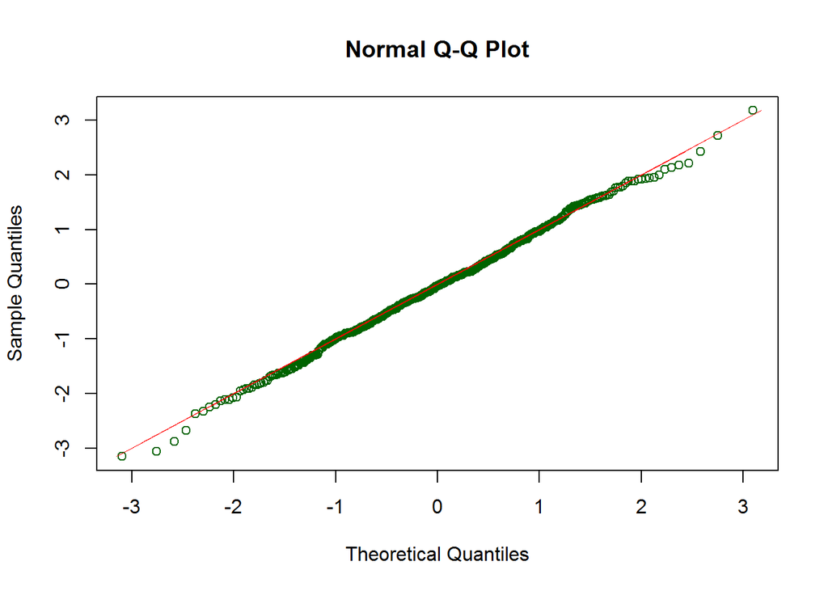

```r
# QQ Norm plot (Copied from plot.gamlss)
residx <- resid(model)
qqnorm(residx, main = "Normal Q-Q Plot",
            xlab = "Theoretical Quantiles",
            ylab = "Sample Quantiles",
            plot.it = TRUE,
            frame.plot = TRUE,
            col="darkgreen")
lines(residx, residx, col="red" , lwd=.4, cex=.4 )
```

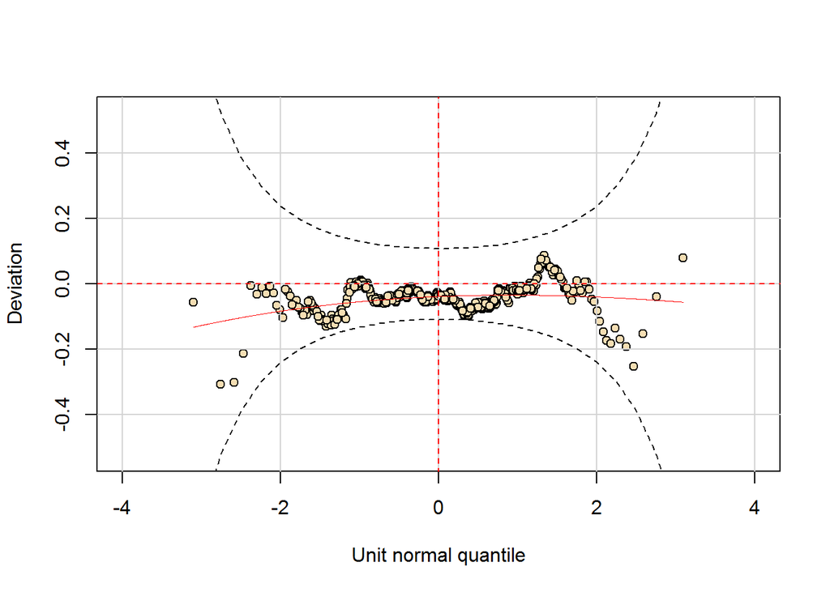

```r
# Worm Plot
wp(model)
```